# Cambridge Response Summary

## Summary

The responses to the South Cambridgeshire Council’s development plan reflect a complex interplay of support and opposition, highlighting a range of concerns and aspirations for the future of Greater Cambridge. Overall, there is a strong emphasis on the need for sustainable development that prioritises green spaces, affordable housing, and improved public transport. Many respondents advocate for the creation of vibrant, mixed-use neighbourhoods that facilitate access to essential services and promote community wellbeing. However, there is also significant apprehension regarding the potential negative impacts of overdevelopment, particularly in rural villages and green belt areas, which could undermine local character and biodiversity.

Key themes include the desire for enhanced public transport and cycling infrastructure to reduce car dependency, the importance of preserving existing green spaces and wildlife habitats, and the need for affordable housing that meets the diverse needs of the community. Respondents express concerns about the adequacy of current infrastructure to support proposed developments, particularly in relation to healthcare and educational facilities. There is a clear call for community engagement in the planning process to ensure that local voices are heard and that developments align with the needs of existing residents.

**OPPOSE**: 45.52% *(310)* | **SUPPORT**: 28.05% *(191)* | **MIXED**: 24.08% *(164)* | **NEUTRAL**: 2.35% *(16)*

## Aim Breakdown

The aim breakdown identifies which aims are mentioned within each response. A single response may discuss multiple topics.

| **Aim** | **Percentage** | **Count** |
| --- | --- | --- |
| Infrastructure | 21.08% | 556 |
| Homes | 17.10% | 451 |
| Biodiversity and green spaces | 15.62% | 412 |
| Wellbeing and social inclusion | 14.40% | 380 |
| Jobs | 12.36% | 326 |

| Place | Count | Mean Sentiment |
| --- | --- | --- |
| Cambourne | 351 | 4.99715 |
| Cambridge Biomedical Campus | 317 | 5.8959 |
| North East Cambridge | 226 | 5.19469 |
| Cambridge | 209 | 4.37321 |
| southern rural cluster of villages | 154 | 3.96104 |

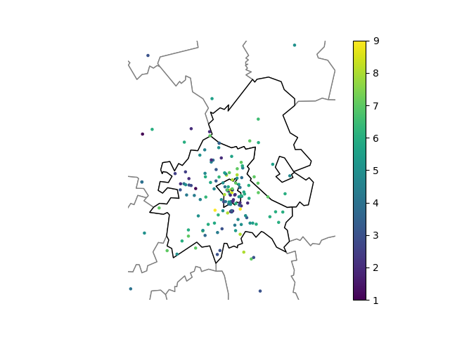

Locations mentioned by sentiment

## Key points raised in support

### Biodiversity and green spaces

- Many respondents advocate for the inclusion of green spaces and parks in new developments to enhance community wellbeing and support local wildlife.
- There is a strong emphasis on preserving existing natural habitats and promoting biodiversity through initiatives like tree planting and the creation of wildlife corridors.

### Homes

- Support for the development of affordable housing, particularly for key workers and families, is prevalent, with calls for a diverse range of housing options to meet community needs.
- Respondents express a desire for housing developments to be integrated with local amenities and services to create self-sufficient communities.

### Infrastructure

- There is a consensus on the need for improved public transport links and cycling infrastructure to facilitate access to jobs and services, reducing reliance on cars.
- Many advocate for the development of transport hubs and better connectivity between residential areas and employment centres.

### Wellbeing and social inclusion

- The importance of community facilities, such as schools, healthcare services, and recreational spaces, is frequently highlighted as essential for fostering social inclusion and enhancing quality of life.
- Respondents call for developments to be designed with accessibility in mind, ensuring that they cater to all demographics, including vulnerable groups.

### Great places

- There is a strong desire for developments to reflect local character and heritage, with calls for high-quality design standards that harmonise with existing architecture.
- Many respondents advocate for the creation of vibrant, mixed-use neighbourhoods that encourage social interaction and community engagement.

## Key points raised in opposition

### Biodiversity and green spaces

- Concerns are raised about the potential loss of green spaces and wildlife habitats due to overdevelopment, particularly in rural areas and the green belt.
- Some respondents oppose developments that encroach on natural reserves, fearing negative impacts on local ecosystems and biodiversity.

### Homes

- There is apprehension regarding the potential for new housing developments to exacerbate existing issues of affordability and overcrowding, particularly if they cater primarily to external investors rather than local residents.
- Some respondents express concerns that the proposed housing targets may not adequately reflect the needs of the community, particularly in light of changing work patterns post-pandemic.

### Infrastructure

- Many express doubts about the adequacy of current infrastructure to support proposed developments, particularly in relation to transport, healthcare, and educational facilities.
- Concerns are raised about traffic congestion and pollution resulting from increased housing density without corresponding improvements in public transport.

### Wellbeing and social inclusion

- Some respondents highlight the risk of social isolation in new developments if they do not include sufficient community facilities and services.
- There are calls for more meaningful community engagement in the planning process to ensure that developments meet the needs of existing residents and do not compromise their quality of life.

### Great places

- Opposition is voiced against developments that are perceived as generic or lacking in character, with calls for more thoughtful, context-sensitive design that enhances the local environment.
- Concerns are raised about the potential for urban sprawl to diminish the unique character of Cambridge and its surrounding villages.

## Summaries

The author expresses mixed support for the SCDC Local Plan H/1e housing site off New Rd, endorsing the green spaces policies but questioning the development’s ability to meet local needs and suggesting there are better alternatives. They also support the decision not to include certain housing site options in the Draft Local Plan.

**Stance**: MIXED

**Constructiveness**: 6

The author objects to the proposed developments at Bourn Airfield and West Cambourne, citing concerns over disproportionate housing growth, traffic congestion, and the impact on local infrastructure. They argue that the burden of new homes should be more evenly distributed across South Cambridgeshire, particularly suggesting reconsideration of rejected sites with better transport links. Additionally, they support the rejection of the North Cambourne development due to its impact on agricultural land, landscape, and local traffic issues, emphasising the rural character of the area.

**Stance**: OPPOSE

**Constructiveness**: 4

The author supports the alteration of public bridleways within Green Infrastructure to enhance leisure routes for walkers, riders, and cyclists, which would benefit the local community and reduce traffic flow. They also advocate for the inclusion of bridleways in the Longstanton policy, emphasizing the importance of conservation areas and green separation.

**Stance**: SUPPORT

**Constructiveness**: 9

The author has submitted comments regarding the planning application but has not provided specific details in the response. They refer to enclosed representations for a more comprehensive overview of their views.

**Stance**: NEUTRAL

**Constructiveness**: 5

The author supports increased housing development in villages, particularly Fen Ditton, arguing that the current plan disproportionately allocates housing to urban areas while neglecting villages. They suggest that Fen Ditton should be designated as a Minor Rural Centre and propose a site for up to 30 dwellings, emphasizing the potential for sustainable growth and enhancement of community services without harming the green belt.

**Stance**: SUPPORT

**Constructiveness**: 8

The author supports the policy on affordable housing but expresses concerns about its practical implementation in a group village setting.

**Stance**: SUPPORT

**Constructiveness**: 7

The author supports the inclusion of Lupin and Merton fields as local green spaces, suggesting that a section of Merton field could be designated as a play area for children, while also advocating for the management of Lupin field as a wildlife and flower area. The author expresses concern about losing these green spaces amidst new housing developments.

**Stance**: SUPPORT

**Constructiveness**: 8

The author supports the designation of site 078 as Local Green Space, confirming it meets the necessary criteria and is backed by the Parish Council. The site, known as “The Rouses”, is integral to the Bassingbourn community, providing a valuable amenity for recreation and maintaining the character of the village. Development would harm this area and remove an important green space.

**Stance**: SUPPORT

**Constructiveness**: 9

The author objects to the proposed housing developments on sites H/1:b and H/1:c due to concerns about inadequate infrastructure, particularly regarding traffic congestion and parking in Sawston. They argue that the developments conflict with national policy on protecting greenbelt land and ensuring the vitality of town centres. The author supports the development of a brownfield site (H/1:a) but believes that the additional developments would strain local resources.

**Stance**: OPPOSE

**Constructiveness**: 4

The author, representing the Swavesey & District Bridleways Association, expresses concern that the South Cambs Local Plan does not adequately address the needs of horseriders as part of the Non-Motorised User (NMU) group. They advocate for the inclusion of equestrian access in the Local Plan, highlighting the benefits of improved facilities for NMUs, such as reduced road traffic, economic development, and enhanced community wellbeing. The author supports comments made by another local group regarding the need for inclusive routes and compliance with national planning policy.

**Stance**: OPPOSE

**Constructiveness**: 8

The response is addressed to various stakeholders regarding a planning application. It highlights the importance of considering local wildlife and access for horse riders, indicating a need for careful planning to ensure that the development does not negatively impact these aspects.

**Stance**: MIXED

**Constructiveness**: 7

The author has submitted comments regarding the planning application, but the details of their stance and specific concerns are not provided in the response.

**Stance**: NEUTRAL

**Constructiveness**: 5

The author opposes the development due to a lack of infrastructure to support the increased population, including concerns about traffic, schools, and healthcare facilities. They also question the necessity of the development in the area.

**Stance**: OPPOSE

**Constructiveness**: 3

The author provides no input or suggestions regarding the development of various areas in Greater Cambridge, including the Cambridge Biomedical Campus, Cambourne, and the southern rural cluster of villages. They express a lack of opinion on housing, jobs, facilities, or open spaces for these sites and do not offer any thoughts on the future of Greater Cambridge.

**Stance**: NEUTRAL

**Constructiveness**: 1

The response from RES UK and Ireland Limited expresses support for the aims of the South Cambridgeshire Local Plan regarding climate change and renewable energy generation. However, it opposes the current wording of Policy S/2, arguing that it does not adequately promote renewable and low carbon energy development, which is essential for sustainable growth. RES suggests amendments to ensure that renewable energy is a key component of the planning framework. The company supports the principles of mitigating climate change and the provision of renewable energy generation, while also raising concerns about the decommissioning policy for energy projects.

**Stance**: MIXED

**Constructiveness**: 7

The author strongly opposes part 2 of Policy CC/2, which proposes a minimum separation distance of 2km between wind turbines and dwellings, arguing that it is unnecessary and contrary to national policy aimed at promoting renewable energy. They assert that the policy is overly restrictive and does not align with the National Planning Policy Framework (NPPF) or Planning Practice Guidance. The author supports Policy CC/3, which encourages the use of on-site renewable energy technologies in new developments. They express concern that the objectives of the Local Plan should better reflect the importance of renewable energy in addressing climate change.

**Stance**: OPPOSE

**Constructiveness**: 4

The author argues that the Policy is unsound because it imposes inflexible rules on separation distances, which contradicts the Planning Practice Guidance for Renewable and Low Carbon Energy. They state that the Policy is not positively planned, justified, or consistent with national planning policy.

**Stance**: OPPOSE

**Constructiveness**: 4

The author expresses apprehension about the development of a dense city district in North East Cambridge, suggesting caution and limits on development, particularly around the Cambridge Biomedical Campus. They question the necessity of more jobs in Cambourne and express concern about saturation in development in the southern rural cluster of villages. The author advocates for limited development in villages and emphasizes the need for radical action to reduce motor traffic and prioritise climate change in future planning.

**Stance**: OPPOSE

**Constructiveness**: 4

The author expresses strong opposition to various proposed developments in Greater Cambridge, arguing that existing infrastructure issues must be addressed before any new projects are considered. They advocate for the preservation of open spaces and green landscapes, particularly in relation to the Cambridge Biomedical Campus and the East-West Rail link.

**Stance**: OPPOSE

**Constructiveness**: 2

The author opposes the redevelopment of the waste water treatment plant, arguing it should not be relocated to a greenfield site. They also oppose any development that would encroach on the green belt, advocate for limited development in villages without improved public transport, and envision a densified, vehicle-free city by 2041.

**Stance**: OPPOSE

**Constructiveness**: 2

The author advocates for the development of a vibrant city district east of Milton Road, suggesting facilities that promote a circular economy, such as allotments and community centres, and emphasises the need for car-free development. They support the expansion of the Cambridge Biomedical Campus with more healthcare facilities but oppose additional housing. The author calls for safe cycling routes to Cambridge from Cambourne and insists on limited development in villages, contingent on car-free initiatives and improved cycling routes. They propose more green spaces and suggest a site north of Barton Road for potential development. Overall, the author envisions a car-free Greater Cambridge by 2041.

**Stance**: SUPPORT

**Constructiveness**: 9

The author advocates for the development of community spaces, green spaces, and affordable housing across various locations including North East Cambridge, the Cambridge Biomedical Campus, Cambourne, and the southern rural cluster of villages. They also suggest the inclusion of active transport routes and low emission zones for a sustainable future in Greater Cambridge.

**Stance**: SUPPORT

**Constructiveness**: 9

The author expresses a vision for the development of areas in Greater Cambridge, advocating for a lively city district east of Milton Road after the relocation of the waste water treatment plant. They suggest that Cambourne should develop into a proper town with centralised transport access and improved services, while maintaining clear natural borders with surrounding villages. The author emphasises the importance of open spaces and natural habitats in any development, particularly in rural areas and villages like Caldecote, and envisions a future with low-rise buildings and abundant green spaces.

**Stance**: MIXED

**Constructiveness**: 7

The author proposes a range of community facilities and green spaces for various development sites in Greater Cambridge, including recreational areas, biodiversity initiatives, healthcare facilities, and support for local businesses. They emphasise the importance of inclusivity and accessibility for all ages and genders, as well as the need for environmental sustainability through biodiversity planting and recycling spaces.

**Stance**: SUPPORT

**Constructiveness**: 9

The author advocates for a variety of community facilities and green spaces, including recreational areas, gardens, and support for local businesses. They emphasize the importance of retaining and strengthening existing policies in the Cambridge Local Plan, particularly regarding specific areas that should be protected from development.

**Stance**: SUPPORT

**Constructiveness**: 9

The author suggests developing the area east of Milton Road into a vibrant city district with housing, jobs, and community facilities, while also supporting the expansion of the Cambridge Biomedical Campus with additional healthcare and green spaces. They express a desire for Cambourne to develop into a proper town and advocate for limited development in villages, showing a preference for areas with good transport links. However, the author conveys a sense of boredom and lack of engagement with the questions posed.

**Stance**: MIXED

**Constructiveness**: 5

The author expresses strong opposition to various proposed developments in Greater Cambridge, highlighting concerns about the loss of green spaces, the impact of housing developments on local areas, and the potential for overdevelopment driven by developers. They advocate for limited development in villages and stress the importance of maintaining the rural character of the area, warning against excessive concrete expansion.

**Stance**: OPPOSE

**Constructiveness**: 2

The author expresses strong opposition to various proposed developments in Greater Cambridge, arguing that they threaten local biodiversity, water resources, and agricultural land. They advocate for prioritising brownfield site development, affordable housing for local workers, and a focus on climate change and water safeguarding research. The author believes that development should be shared equitably among villages and that existing permissions should be fully realised before further allocations are made. They call for a shift in priorities towards environmental conservation rather than continued expansion.

**Stance**: OPPOSE

**Constructiveness**: 2

The author suggests that development in villages should be very limited, advocating for new developments only in villages that already have local services, including healthcare access.

**Stance**: OPPOSE

**Constructiveness**: 4

The author advocates for the development of a vibrant city district east of Milton Road in North East Cambridge, emphasizing the need for high-density housing with efficient transport links and local independent businesses. They also stress the importance of transport capacity at the Cambridge South railway station to support the Cambridge Biomedical Campus, and call for easy and affordable transport options in Cambourne to prevent car dependency. Additionally, they highlight the necessity of good transport links in the southern rural cluster of villages. The author suggests looking to the Netherlands as a model for Greater Cambridge’s future development.

**Stance**: SUPPORT

**Constructiveness**: 9

The author strongly opposes any further development in Greater Cambridge, arguing that it would stretch the city’s already constrained infrastructure. They express this sentiment consistently across various proposed developments, including areas east of Milton Road, the Cambridge Biomedical Campus, Cambourne, and rural villages.

**Stance**: OPPOSE

**Constructiveness**: 1

The author supports the development of various areas in Greater Cambridge, advocating for increased housing, improved cycling infrastructure, and prioritisation of bike lanes over car access. They express a need for more homes in the Cambridge Biomedical Campus and Cambourne, and suggest that villages with good transport links should also see development. The author criticises the current use of land in the Newmarket Road area, calling for it to be repurposed for housing and community facilities. Overall, they endorse high environmental standards and a vision of reduced car dependency by 2041.

**Stance**: SUPPORT

**Constructiveness**: 9

The author expresses strong opposition to various proposed developments in Greater Cambridge, advocating for the preservation of open spaces and the green belt. They highlight concerns about overdevelopment, particularly in areas like the Cambridge Biomedical Campus, and suggest that any necessary transport developments should be electric rather than diesel. The response consistently calls for limited development and prioritises open spaces over housing or commercial facilities.

**Stance**: OPPOSE

**Constructiveness**: 2

The author strongly opposes the proposed developments in various areas, advocating for the protection of natural spaces and expressing concerns about climate change and pollution. They suggest re-wilding areas instead of developing them, and highlight the need for open spaces rather than more buildings. The author also raises issues regarding the safety of existing infrastructure and the importance of preserving rural life.

**Stance**: OPPOSE

**Constructiveness**: 2

The author supports the development of the Cambridge Biomedical Campus for healthcare facilities, research, and housing, suggesting the creation of semi-natural areas linked to Hobson’s Park. However, they oppose the current East-West Rail route and advocate for better, larger, and more connected wild areas in Greater Cambridge by 2041.

**Stance**: MIXED

**Constructiveness**: 6

The author advocates for the development of housing and facilities in Greater Cambridge that are socially inclusive, catering to a diverse range of occupations beyond just office-based jobs. They emphasize the importance of local employment opportunities in villages to prevent them from becoming exclusive areas for wealthier residents. Additionally, they raise concerns about the need for resilient electrical power generation systems in the face of climate change and potential threats.

**Stance**: SUPPORT

**Constructiveness**: 9

The author advocates for the development of green, natural parks with trees and lakes in various areas, including the site east of Milton Road, around the Cambridge Biomedical Campus, Cambourne, and the southern rural cluster of villages. They express a preference for limited development in villages and suggest no new development in certain areas, while consistently emphasising the importance of green spaces.

**Stance**: SUPPORT

**Constructiveness**: 9

The author strongly opposes the proposed development in North East Cambridge, arguing that the relocation of the sewage works is profit-driven and unnecessary, as the current facility has sufficient capacity until 2050. They express concern over the lack of transparency regarding the sewage works’ status as a nationally significant infrastructure project and criticize the potential loss of Green Belt land. Additionally, the author is critical of the approach to development in Cambourne and surrounding villages, advocating for gradual, small-scale development rather than large-scale projects that disrupt communities and the countryside.

**Stance**: OPPOSE

**Constructiveness**: 2

The author expresses concerns about the development of a dense city district east of Milton Road, suggesting a preference for outdoor garden spaces over flats. They support the expansion of the Cambridge Biomedical Campus for local jobs and healthcare facilities but emphasize the need for jobs for local residents. The author is unsure about the current situation in Cambourne and the southern rural cluster of villages, suggesting limited development in villages with good transport links. They recommend Waterbeach for new development, specifically advocating for better shopping facilities.

**Stance**: MIXED

**Constructiveness**: 6

The author strongly opposes the proposed developments in various areas, expressing concerns that they will lead to overdevelopment and negatively impact the character of Cambridge and its surrounding villages. They argue that the city is already overdeveloped and that further construction will ruin its beauty and livability.

**Stance**: OPPOSE

**Constructiveness**: 2

The author expresses strong reservations about development in various areas, insisting that no new projects should proceed without adequate water management and public transport infrastructure. They advocate for preserving the character of existing villages and enhancing green spaces, while showing a lack of specific suggestions for new developments.

**Stance**: OPPOSE

**Constructiveness**: 3

The author advocates for the development of social housing in various areas, including the east of Milton Road, the Cambridge Biomedical Campus, Cambourne, and Cottenham, while expressing concerns about restrictions on who can move into these areas. They suggest that more housing, shops, and facilities should be provided, particularly social housing without local connection restrictions. The author also highlights the need for better public transport and local services in villages, and calls for a more inclusive approach to housing development.

**Stance**: SUPPORT

**Constructiveness**: 7

The author advocates for the development of a vibrant city district east of Milton Road in North East Cambridge, emphasizing the need for affordable housing, ample parking with EV charging, sustainable energy solutions, and various community facilities including schools, shops, and recreational areas. They also support the expansion of the Cambridge Biomedical Campus with more healthcare facilities and housing, and suggest similar developments in Cambourne and the southern rural cluster, while expressing concerns about the current transport infrastructure in villages. The author calls for improved connectivity for South Cambridgeshire to enhance access to services and leisure facilities.

**Stance**: SUPPORT

**Constructiveness**: 9

The author expresses a preference for limited development in the area east of Milton Road in North East Cambridge, supports the expansion of the Cambridge Biomedical Campus, opposes growth in Cambourne, and advocates for minimal development in rural villages, preferring to maintain their current state. They envision Greater Cambridge remaining rural and happy by 2041.

**Stance**: OPPOSE

**Constructiveness**: 4

The author expresses concerns about various proposed developments in Greater Cambridge, particularly regarding the need for appropriate housing and facilities that cater to local communities rather than external speculators. They support the development of the Cambridge Biomedical Campus but highlight the need for improvements to existing facilities. The author is critical of the East-West Rail link, suggesting it disrupts local communities and does not provide a sustainable solution. They advocate for limited development in villages, emphasizing the importance of public transport and local needs. Overall, the response reflects a cautious approach to development, prioritising community needs and sustainability.

**Stance**: MIXED

**Constructiveness**: 6

The author expresses opposition to various proposed developments in Greater Cambridge, particularly concerning housing in green belt areas and around existing facilities like the Cambridge Biomedical Campus. They advocate for maintaining agricultural land and limiting housing developments to small numbers in villages. The author supports the idea of enhancing existing facilities and infrastructure, such as healthcare and shops, while discouraging further housing in crowded areas. They also emphasise the importance of concentrating developments in Cambridge to promote sustainable transport options.

**Stance**: OPPOSE

**Constructiveness**: 4

The author expresses a desire for affordable and social housing in the proposed developments, particularly in the area east of Milton Road and around the Cambridge Biomedical Campus. They are uncertain about specific developments in Cambourne and the southern rural cluster of villages, indicating that the suitability of these areas depends on their exact locations. The author also raises concerns about the potential negative impacts of development on the quality of life for existing residents, particularly regarding congestion and infrastructure needs.

**Stance**: MIXED

**Constructiveness**: 6

The author advocates for the development of the area east of Milton Road in North East Cambridge into a vibrant city district, emphasising the need for more open space than currently proposed. They also highlight the necessity for improved transport infrastructure, including bike parking, safe pedestrian routes, and reliable public transport services.

**Stance**: SUPPORT

**Constructiveness**: 7

The author expresses strong opposition to the expansion of the Cambridge Biomedical Campus, advocating for the development of a second site to distribute growth more evenly. They criticise the East-West Rail project as inadequate for local transport needs and suggest it should focus on broader connectivity. Concerns are raised about the impact of infill development on southern villages, calling for improved transport infrastructure before any further development. The author advocates for more outdoor recreational facilities and a balanced approach to job creation, particularly in manufacturing, to diversify the local economy. They emphasise the need for Greater Cambridge to lead in environmental action and social well-being.

**Stance**: OPPOSE

**Constructiveness**: 4

The author strongly opposes the development of the area east of Milton Road in North East Cambridge, arguing that relocating the waste water treatment plant is unnecessary and financially unfeasible. They express concerns about the impact on green belt and agricultural land, describing the proposed development as destructive to the local community and conservation areas. The author dismisses the need for additional healthcare facilities at the Cambridge Biomedical Campus, criticises the affordability of rail travel for Cambourne, and opposes any development in the southern rural cluster of villages. They advocate for listening to local populations regarding development and express a general discontent with the direction of growth in Greater Cambridge, fearing it will lead to a loss of community and democratic engagement.

**Stance**: OPPOSE

**Constructiveness**: 2

The author expresses support for the development of the Cambridge Biomedical Campus and the potential for growth in Cambourne, but raises concerns about the specifics of what constitutes a ‘proper town’ and the need for more retail options. They advocate for limited development in villages, emphasizing the importance of maintaining village character and prioritizing brownfield sites for housing over greenfield sites.

**Stance**: MIXED

**Constructiveness**: 6

The author expresses strong opposition to the proposed developments in various areas, arguing that the density of housing in North East Cambridge could lead to future slum conditions, that the Cambridge Biomedical Campus should focus solely on biomedical uses without housing, and that Cambourne has already taken on enough housing without additional development. They stress the need for sustainable housing, proper facilities, and the preservation of existing leisure areas before any new housing is built.

**Stance**: OPPOSE

**Constructiveness**: 2

The author expresses opposition to relocating the waste water treatment plant, arguing it would waste money and green belt land. They advocate for improved safety for pedestrians and cyclists around Addenbrookes, suggest replacing oil with greener technologies in rural villages, and oppose developing green belt land. The author calls for more greenery, better public transport, and sustainable building practices in Greater Cambridge by 2041.

**Stance**: OPPOSE

**Constructiveness**: 4

The author suggests that Cambourne should develop various facilities including a swimming pool, adventure playground, and more retail options. They advocate for limited development in villages, recommending Gamlingay and Bourn for new sites. Additionally, they propose Barton for housing or business use and express a desire for more affordable parking and out-of-town shopping areas, as well as country parks to enhance the countryside experience.

**Stance**: MIXED

**Constructiveness**: 7

The author expresses frustration over the lack of promised developments in Cambourne, including a high street, swimming pool, and adequate healthcare and sports facilities. They highlight the absence of local jobs, forcing residents to travel to Cambridge, and criticise the slow public transport. The author calls for improved infrastructure and the establishment of entertainment venues and retail parks to reduce reliance on travel to Cambridge.

**Stance**: OPPOSE

**Constructiveness**: 4

The author supports the development of the Cambridge Biomedical Campus, suggesting the addition of healthcare facilities, housing, and open spaces. They advocate for Cambourne to develop into a proper town with healthcare jobs and facilities. The author believes that the southern rural cluster of villages should see limited development, particularly in Shelford and Stapleford, with a focus on mixed and lower-cost housing, a supermarket, and quality recreation facilities. They express a desire to maintain the distinction between city and villages while improving planning for electric vehicles and low-carbon transportation options.

**Stance**: SUPPORT

**Constructiveness**: 9

The author opposes further development in Melbourn, citing recent housing increases that have outstripped local infrastructure, particularly in healthcare and education. They advocate for maintaining the current state of the village.

**Stance**: OPPOSE

**Constructiveness**: 4

The author expresses strong opposition to various proposed developments in Greater Cambridge, arguing that they would lead to a loss of character and livability in the area. They specifically criticise the idea of a dense city district, the expansion of the Cambridge Biomedical Campus, and any development near diesel rail lines, advocating instead for the preservation of open spaces and historical architecture.

**Stance**: OPPOSE

**Constructiveness**: 2

The author suggests that the area east of Milton Road in North East Cambridge, currently housing a waste water treatment plant, has potential for development into a vibrant city district once the plant is relocated. They specifically mention the need for parks and open spaces in this new development.

**Stance**: SUPPORT

**Constructiveness**: 7

The author expresses a vision for the development of various areas in Greater Cambridge, advocating for the inclusion of essential facilities such as schools, healthcare services, and leisure spaces. They support the development of the Cambridge Biomedical Campus but call for improved transport links. However, they oppose development in the southern rural cluster of villages and stress the importance of preserving the rural character of the county, suggesting that only brownfield sites should be used for new developments.

**Stance**: MIXED

**Constructiveness**: 6

The author advocates for the development of a vibrant city district east of Milton Road in North East Cambridge, suggesting the inclusion of outdoor entertainment for families and young people. They also support the expansion of the Cambridge Biomedical Campus with additional healthcare facilities, research, and housing, emphasizing the need for sports facilities to promote health and fitness. Furthermore, the author expresses a desire for Greater Cambridge to achieve world-leading environmentally sustainable transport and housing by 2041, criticizing the current situation.

**Stance**: SUPPORT

**Constructiveness**: 8

The author expresses strong opposition to various proposed developments in Greater Cambridge, particularly in rural areas and green spaces, citing concerns over environmental impact and the importance of preserving natural habitats. They advocate for limited development focused on brownfield sites and emphasize the need for healthcare, schools, and local services in urban areas, while rejecting large-scale developments that threaten green land.

**Stance**: OPPOSE

**Constructiveness**: 4

The author supports the development of the Cambridge Biomedical Campus for healthcare, research, and housing, emphasising the need for affordable housing to retain graduates. They advocate for improved transport links and facilities in Cambourne and the southern rural cluster, including better access between villages and the creation of a large country park. The author suggests developing a new village with essential amenities and highlights the need for a pedestrian route and cycle path near Meldreth. They envision Greater Cambridge as a more affordable place for young people with more family-friendly activities.

**Stance**: SUPPORT

**Constructiveness**: 9

The author suggests that the area east of Milton Road in North East Cambridge could be developed into a vibrant city district after relocating the waste water treatment plant. They support the expansion of the Cambridge Biomedical Campus with additional healthcare facilities, research, and housing. They believe East-West Rail presents an opportunity for Cambourne to develop into a proper town. However, they oppose any development in the southern rural cluster of villages and advocate for limited development in villages with good public transport. The author also highlights the need to address traffic issues in Greater Cambridge by 2041.

**Stance**: MIXED

**Constructiveness**: 6

The author suggests that the southern rural cluster of villages near the rail line and business parks south of Cambridge could accommodate limited development, specifically highlighting the need for more schools and GPs in the area.

**Stance**: MIXED

**Constructiveness**: 7

The author expresses a strong opposition to any new housing or development in Greater Cambridge, advocating for the preservation of existing land and the character of villages. They reject the idea of expanding housing in various proposed areas, including the Cambridge Biomedical Campus and Cambourne, and do not support any development in villages, emphasising a desire to maintain their current state.

**Stance**: OPPOSE

**Constructiveness**: 2

The author criticises the North East Cambridge development plan, arguing that it is flawed due to the unnecessary relocation of the Waste Water Treatment Works to green field Green Belt Land. They assert that the development should not depend on this relocation.

**Stance**: OPPOSE

**Constructiveness**: 3

The author suggests developing the area east of Milton Road in North East Cambridge into a vibrant city district with diverse shops and faith centres. They support the expansion of the Cambridge Biomedical Campus with housing for on-call staff and affordable accommodation for families. They advocate for more local shopping in Cambourne and the preservation of rural walks. The author believes development in villages should be limited to those with good transport links, and they propose potential development sites along the A1307 due to the A14 improvements.

**Stance**: MIXED

**Constructiveness**: 7

The author expresses strong opposition to the proposed developments in North East Cambridge, particularly criticizing the lack of environmental consideration, the relocation of the waste water treatment plant, and the impact on local green spaces. They advocate for lower density housing, better public transport, and the protection of the green belt. The response also highlights concerns about the aesthetic quality of new developments and the need for more imaginative planning. Overall, the author fears that Cambridge will become an unattractive and unsustainable place to live.

**Stance**: OPPOSE

**Constructiveness**: 2

The author expresses concerns about the appropriateness of further development in the congested area east of Milton Road in North East Cambridge. They support the development of the Cambridge Biomedical Campus, suggesting improvements in public transport, local shops, and a variety of housing options. They advocate for the growth of Cambourne, highlighting the need for more shops and a cottage hospital. The author suggests limited development in the southern rural cluster of villages, proposing more housing along the Cambridge Royston railway and a regional shopping/sports centre. They recommend specific villages for new development and emphasize the need for improved shopping, sports centres, and public transport services. Additionally, they suggest developing more homes in the south-west of the area and envision Greater Cambridge as a world-leading centre of technical excellence by 2041.

**Stance**: MIXED

**Constructiveness**: 6

The author suggests that the development should include numerous parks and safe play areas for children.

**Stance**: SUPPORT

**Constructiveness**: 7

The author strongly opposes any new development in Greater Cambridge, expressing a desire to maintain the current state of the area and criticising the council for prioritising housing over community needs. They specifically reject proposals for housing and facilities in various locations, including the Cambridge Biomedical Campus and Cambourne, and call for a halt to all new housing projects, suggesting that the focus should be on preserving the character of the area rather than accommodating more residents.

**Stance**: OPPOSE

**Constructiveness**: 2

The author advocates for high-density housing development in various areas, including the east of Milton Road, around the Cambridge Biomedical Campus, Cambourne, and the southern rural cluster of villages. They emphasise the need for housing to alleviate the current housing shortage, reduce commuting, and support local economies. The response also suggests utilising existing retail parks for housing and promoting active travel in Greater Cambridge by 2041.

**Stance**: SUPPORT

**Constructiveness**: 9

The author opposes the development of the area east of Milton Road due to the economic implications of relocating the waste water treatment plant. They support the expansion of the Cambridge Biomedical Campus for healthcare and research but suggest improving access to the city centre instead of new housing. The author disagrees with the proposal for Cambourne’s growth and advocates for the protection of surrounding villages from development. They emphasise the need for open spaces and green corridors rather than further development, expressing a strong stance against greedy developers in Cambridgeshire.

**Stance**: OPPOSE

**Constructiveness**: 2

The author suggests developing the area east of Milton Road in North East Cambridge into a vibrant city district with a mix of housing types, various job opportunities, schools, and recreational open spaces. They also support the expansion of the Cambridge Biomedical Campus with additional healthcare facilities and housing, while advocating for recreational spaces. In Cambourne, they express a need for development that mitigates wind exposure. Lastly, they express doubt about the acceptance of new developments in villages, suggesting limited development only in well-connected areas.

**Stance**: MIXED

**Constructiveness**: 6

The author strongly opposes any further housing development in Cambourne, citing a lack of resources, increasing traffic issues, and a departure from the original vision of interconnected villages with town attributes.

**Stance**: OPPOSE

**Constructiveness**: 2

The author expresses no opinion on the development east of Milton Road but supports the expansion of the Cambridge Biomedical Campus, emphasizing the need to protect the Magog Hills. They advocate for improved transport links to Cambourne through the East-West Rail, highlighting the necessity for more local facilities and a proper town centre. The author is critical of overcrowded housing developments in Upper Cambourne and calls for more spacious living conditions. They also stress the importance of enhancing public transport services to reduce car dependency and improve access to employment opportunities.

**Stance**: MIXED

**Constructiveness**: 7

The author agrees that East-West Rail could facilitate growth in Cambourne but insists that the route must serve the majority of proposed developments, including Northstowe. They advocate for all new houses to include solar panels and centralized water storage. However, they oppose any significant development in the southern rural cluster of villages, arguing that there is no need for additional facilities, jobs, or open spaces. They believe that village life should be preserved and that existing facilities are sufficient. The author expresses concern about the impact of development on the character of Cambridge and surrounding villages, urging for their beauty and individuality to be maintained.

**Stance**: OPPOSE

**Constructiveness**: 4

The author strongly opposes various proposed developments in Greater Cambridge, expressing concerns about urbanisation, pollution, and the impact on local communities. They advocate for limited development in villages with good transport links and suggest that existing housing plans are excessive.

**Stance**: OPPOSE

**Constructiveness**: 2

The author supports the development of the Cambridge Biomedical Campus with a focus on affordable housing for essential workers. They express concern about overdevelopment in the northern and western areas of Cambridge, advocating for significant development in the southern region to improve transport links and reduce reliance on cars. The author believes that villages in the south should also accommodate development similar to that in the north, particularly near railway lines and the East-West rail link. They stress the importance of maintaining car infrastructure until public transport can adequately meet diverse travel needs.

**Stance**: SUPPORT

**Constructiveness**: 8

The author opposes the development of the area east of Milton Road due to the recent upgrade of the wastewater treatment plant and the high costs of relocation. They advocate for housing to be built at the relocated plant site instead. They support the development of the Cambridge Biomedical Campus with a focus on vast open spaces and community centres, while opposing development in Cambourne and the southern rural cluster of villages. They suggest Grantchester for limited development and propose road bypasses for villages. They also mention Barton and Newnham as potential sites for development, expressing a desire for Greater Cambridge to remain underdeveloped and preserved by 2041.

**Stance**: OPPOSE

**Constructiveness**: 4

The author expresses strong opposition to the proposed developments in Greater Cambridge, arguing that they would lead to the destruction of green spaces and exacerbate climate change. They advocate for minimal housing and more open spaces, particularly around the Cambridge Biomedical Campus, and suggest that the development plans do not adequately address climate emergency challenges.

**Stance**: OPPOSE

**Constructiveness**: 2

The author expresses a preference for limited development in the area east of Milton Road in North East Cambridge, suggesting it could become a vibrant city district after relocating the waste water treatment plant. They support the expansion of the Cambridge Biomedical Campus with additional healthcare facilities and parkland. However, they oppose further housing in Cambourne, advocating for the preservation of ancient woodlands and farmland. The author is against any new development in villages, emphasising the need for open spaces. They also express skepticism about the planning process, suggesting a lack of transparency.

**Stance**: OPPOSE

**Constructiveness**: 4

The author suggests that the area east of Milton Road in North East Cambridge should be developed into a vibrant city district with housing, jobs, and facilities, particularly after relocating the waste water treatment plant. They advocate for supporting the Cambridge Biomedical Campus with additional healthcare facilities and affordable housing. In Cambourne, they express concerns about insufficient medical services and the need for more retail and educational facilities, suggesting that further development is contingent on these services. They recommend limited development in villages with good public transport and local amenities, and emphasize the need for increased capacity in existing amenities. The author also expresses a desire for fewer large luxury homes in Greater Cambridge by 2041.

**Stance**: MIXED

**Constructiveness**: 7

The author expresses no opinion on various proposed developments in Greater Cambridge, including the area east of Milton Road, the Cambridge Biomedical Campus, Cambourne, the southern rural cluster of villages, and potential sites for housing or business use. They also do not provide any thoughts on the future vision for Greater Cambridge in 2041.

**Stance**: NEUTRAL

**Constructiveness**: 1

The author advocates for the development of a strong cycle network and small homes in various areas, including the east of Milton Road, around the Cambridge Biomedical Campus, and in Cambourne. They express a need for more wild areas and forests, highlighting local residents’ willingness to invest in such projects. The response also calls for a future with more forested areas and fewer cars.

**Stance**: SUPPORT

**Constructiveness**: 9

The author advocates for the development of a vibrant city district east of Milton Road in North East Cambridge, suggesting the inclusion of a major theatre/concert hall, artists’ studios, and large outdoor spaces for sports and health. They also support the growth of Cambourne into a proper town with leisure facilities, shops, and green spaces. The author opposes the transformation of border villages into suburbs, recommending that development should focus on standalone villages with good transport links and local employment opportunities. They emphasize the importance of facilitating local businesses to recruit from the local population.

**Stance**: SUPPORT

**Constructiveness**: 8

The author expresses skepticism about relocating the water treatment facility but supports the development of the Cambridge Biomedical Campus with more housing and a large park. They are unfamiliar with Cambourne and suggest re-establishing rail stations in Cherry Hinton and extending connections to Teversham and Fulbourn. The author advocates for improved public transport connections to benefit more villages.

**Stance**: MIXED

**Constructiveness**: 6

The author opposes development in the southern rural cluster of villages near Cambridge, arguing that the area is quaint and should not be built upon. They express strong concerns about the lack of good public transport connections in villages and stress the need for frequent, reliable, and affordable public transport as a priority. The author advocates for local amenities such as shops, cafes, and parks within walking distance, and highlights the importance of a well-connected transport network to reduce reliance on cars and avoid traffic congestion.

**Stance**: OPPOSE

**Constructiveness**: 4

The author expresses concerns about the proposed housing density in North East Cambridge, arguing it would degrade the quality of life and the city’s character. They advocate for more cultural and social spaces around the Cambridge Biomedical Campus, suggest a mix of employment opportunities in Cambourne, and recommend limited development in villages. Overall, they feel that the current development plans are excessive for Cambridge.

**Stance**: OPPOSE

**Constructiveness**: 4

The author supports the development of the Cambridge Biomedical Campus, advocating for the inclusion of more affordable housing, jobs, and healthcare facilities in the area.

**Stance**: SUPPORT

**Constructiveness**: 9

The author advocates for the development of various areas in Greater Cambridge, emphasising the need for carbon net-zero housing, green spaces, and facilities that accommodate wheelchair users. They express a desire for a mix of housing, jobs, and amenities across different sites, while highlighting the importance of public transport and the use of brownfield sites for development.

**Stance**: SUPPORT

**Constructiveness**: 9

The author advocates for the development of public open spaces in the area east of Milton Road in North East Cambridge, emphasising the need for sufficient space to benefit existing residents. They oppose further development at the Cambridge Biomedical Campus, citing concerns over green belt encroachment. They suggest Sawston as a suitable location for new development in villages and recommend creating travel hubs instead of park-and-ride facilities to promote car-free travel into Cambridge.

**Stance**: MIXED

**Constructiveness**: 6

The author expresses uncertainty regarding specific developments in various areas, including the potential for a city district east of Milton Road, the Cambridge Biomedical Campus, Cambourne, and the southern rural cluster of villages. They suggest limited development in villages with good public transport connections and highlight the importance of public transport and healthcare facilities in planned developments. Overall, they find the current plan focusing on larger villages and towns sensible.

**Stance**: NEUTRAL

**Constructiveness**: 6

The author expresses strong opposition to the proposed development of a dense city district east of Milton Road, citing concerns over overcrowding and the need for more open spaces and better public transport. They also advocate for the development of the Cambridge Biomedical Campus but stress the importance of avoiding segregation in housing. The author questions the use of diesel for the East-West Rail and criticises the overall lack of infrastructure and affordable transport in Cambridge. They call for more parks, leisure areas, and eco-friendly initiatives, while opposing any new development in villages without good transport links.

**Stance**: OPPOSE

**Constructiveness**: 2

The author supports the development of the Cambridge Biomedical Campus for healthcare facilities, research, and housing but raises concerns about increased traffic congestion and the need for improved emergency care capacity. They advocate for more flexible development in villages with good transport links and express worries about the healthcare system’s ability to cope with the growing population in Cambridge.

**Stance**: MIXED

**Constructiveness**: 6

The author supports the development of various areas in Greater Cambridge, including the east of Milton Road, the Cambridge Biomedical Campus, Cambourne, and the southern rural cluster of villages, while advocating for limited development in villages due to inadequate infrastructure. They emphasise the need for housing, jobs, facilities, and open spaces, particularly focusing on enhancing green spaces and community renewable energy projects. The author envisions a carbon-neutral future with a thriving natural environment and sustainable economic principles.

**Stance**: SUPPORT

**Constructiveness**: 9

The author advocates for the development of a vibrant city district east of Milton Road in North East Cambridge, emphasizing the need for cycle lanes, direct access to the river, and wild green spaces. They also stress the importance of local shops to avoid a sterile suburb feel. Additionally, they support the expansion of the Cambridge Biomedical Campus with more healthcare facilities and housing, while suggesting that village developments should be limited to select hubs with good transport links. The author highlights the necessity of direct routes to essential shops and improved public transport connections to tourist sites outside Cambridge.

**Stance**: SUPPORT

**Constructiveness**: 9

The author expresses concerns about the lack of leisure facilities, healthcare services, and affordable housing in proposed developments in North East Cambridge and around the Cambridge Biomedical Campus. They advocate for the inclusion of local amenities in villages and suggest that development should not be limited to Cambridge alone, urging for investment in surrounding areas. The author stresses the importance of ensuring infrastructure is in place before any new developments occur, questioning the effectiveness of the previous local plan.

**Stance**: OPPOSE

**Constructiveness**: 4

The author strongly opposes any additional development around the Cambridge Biomedical Campus, arguing that existing communities are already overwhelmed and that no further housing should be added. They also oppose the East-West Rail project, suggesting that funds should be redirected to northern areas instead. The author believes there should be no new development in the southern rural cluster of villages or in any villages, advocating for the preservation of the green belt and the support of existing developments only. They express concerns about water availability for future plans and envision a Greater Cambridge in 2041 that is improved but not expanded.

**Stance**: OPPOSE

**Constructiveness**: 2

The author strongly opposes the proposed development in Great Shelford, citing concerns about the importance of green belt land for maintaining separation between villages, poor access, increased traffic congestion, and pressure on local schools. They believe the development will not support sustainable travel and will primarily benefit developers rather than the community. Additionally, they express concern about the overall number of homes planned too close to Cambridge, advocating for housing to be located outside the green belt.

**Stance**: OPPOSE

**Constructiveness**: 2

The author opposes the proposed development in the green belt area of Shelford/Stapleford, citing concerns about the merging of the villages, erosion of green belt protection, increased traffic, and safety risks associated with additional housing. They suggest that housing should be planned in a more distant village to promote rail use instead of car dependency.

**Stance**: OPPOSE

**Constructiveness**: 4

The author believes that development in villages should be very limited, suggesting that only a few sites in well-connected villages should be considered. They also express a desire for future developments to have character, contrasting them with recent developments near Addenbrooke’s.

**Stance**: OPPOSE

**Constructiveness**: 4

The author advocates for the development of various areas in Greater Cambridge, emphasising the need for mixed-use developments that include housing, jobs, facilities, and open spaces to foster community. They support the expansion of the Cambridge Biomedical Campus with additional healthcare and housing, and stress the importance of self-sufficiency in Cambourne to reduce travel. The author suggests limited development in villages, focusing on brownfield sites and ensuring essential services like schools and healthcare are available. They do not propose any new sites for development beyond those already identified.

**Stance**: SUPPORT

**Constructiveness**: 9

The author opposes the relocation of the sewage works, arguing that it would negatively impact green belt land. They also express concerns about traffic congestion around the Cambridge Biomedical Campus, suggesting that no further development should be pursued in that area.

**Stance**: OPPOSE

**Constructiveness**: 3

The author advocates for the development of a vibrant city district east of Milton Road with carbon-neutral housing and starter homes for young families. They support the expansion of the Cambridge Biomedical Campus with additional healthcare facilities while urging the preservation of the Nine Wells nature reserve. They suggest creating local community hubs in Cambourne, including cafes and shops, while ensuring access to green spaces. The author expresses caution about limited development in villages to maintain their character and raises concerns about the impact of increased remote working. They propose transforming the Grafton Centre into housing with a design that complements Cambridge’s skyline. Lastly, they envision a future town that is resilient to climate change and safe for future generations.

**Stance**: SUPPORT

**Constructiveness**: 9

The author opposes the proposed development site in Shelford, arguing that it is poorly chosen as it threatens to merge the communities of Great Shelford and Stapleford and could lead to further sprawl into the green belt. They also express concerns about inadequate access to the site, which may exacerbate traffic issues at the level crossing, and warn that such developments could encourage more building in other green belt areas.

**Stance**: OPPOSE

**Constructiveness**: 4

The author expresses concerns that the development plan lacks genuine sustainability and suggests better use of existing rail routes, such as Ashwell & Morden and Meldreth, to improve transport links. They advocate for sustainable transport options to reduce dependence on private cars in Cambridge.

**Stance**: OPPOSE

**Constructiveness**: 4

The author suggests that limited development could occur in the southern rural cluster of villages near the rail line and business parks south of Cambridge, while emphasising the importance of maintaining the village identity in Greater Cambridge by 2041.

**Stance**: MIXED

**Constructiveness**: 7

The author strongly opposes the proposed development site in Shelford, arguing that it does not meet the criteria for exceptional circumstances to remove land from the green belt. They express concerns about increased car usage by new homeowners and the potential blending of Shelford and Stapleford, which the green belt aims to prevent. Additionally, they highlight the risk of further encroachment on the area due to nearby transport links.

**Stance**: OPPOSE

**Constructiveness**: 3

The author supports the development of the Cambridge Biomedical Campus, advocating for more diverse and human-scale buildings, including shops and cafes. They express a need for a better town centre in Cambourne and suggest limited development in villages, specifically mentioning Cottenham. The author emphasises the importance of improved public transport, suggesting a metro system to reduce reliance on cars.

**Stance**: SUPPORT

**Constructiveness**: 8

The author expresses support for the development of the Cambridge Biomedical Campus, suggesting the addition of a railway station to enhance accessibility. They advocate for limited development in villages, focusing on new communities rather than altering existing ones, and highlight the need for improved broadband in rural areas to facilitate remote work and reduce carbon footprints. The author also notes the rising housing demand due to the influx of skilled workers in the area, emphasizing the need for diverse housing options.

**Stance**: SUPPORT

**Constructiveness**: 8

The author expresses concerns about the scale of proposed developments in various areas, emphasising the need for affordable housing and high environmental standards. They highlight potential environmental impacts, particularly regarding biodiversity and public transport access, while supporting limited development in rural areas and advocating for renewable energy solutions.

**Stance**: MIXED

**Constructiveness**: 6

The author suggests that all developments with more than 10 new homes should undergo a Whole Life Cycle (WLC) assessment, arguing that the current threshold of 150 is too high. They also advocate for no new car parking facilities in new developments.

**Stance**: OPPOSE

**Constructiveness**: 6

The author expresses opposition to relocating the sewage works to facilitate housing, arguing that Cambridge is becoming too dense and that green spaces are essential for residents. They advocate for recreational facilities around the Cambridge Biomedical Campus and stress the importance of consulting villages on development. The author emphasizes the need to preserve the green belt, protect wildlife, and ensure sustainable building practices to reduce carbon usage and promote mental health.

**Stance**: OPPOSE

**Constructiveness**: 4

The author expresses a desire for balanced development in various areas, advocating for affordable housing, healthcare facilities, and open spaces while cautioning against excessive density and the creation of commuter towns. They highlight the importance of accommodating driving and cycling infrastructure, particularly in relation to the Cambridge Biomedical Campus and the expansion of Cambourne. Specific locations mentioned for development include Histon, Impington, and the Milton Road Impington project.

**Stance**: MIXED

**Constructiveness**: 7

The author expresses opposition to the relocation of the waste water treatment plant, advocating for its current location. They support the Cambridge Biomedical Campus but raise concerns about the existing strain on Addenbrookes Hospital. The author questions the need for further development in Cambourne and the southern rural cluster, suggesting that existing plans should be allowed to settle before new developments are considered. They oppose additional development in Meldreth and Melbourn due to capacity issues and advocate for more recreational facilities for youth. The author also criticizes the relocation of City Council offices to Alconbury due to lack of public transport access.

**Stance**: OPPOSE

**Constructiveness**: 4

The author expresses concerns about the proposed developments in various areas, including Milton Road, the Cambridge Biomedical Campus, Cambourne, and surrounding villages. They highlight issues such as inadequate parking for staff at healthcare facilities, the need for better transport links, and the impact of new developments on local environments and farming land. The author advocates for limited development in villages and suggests that Cambridge should aim for a car-free environment with improved public transport options.

**Stance**: OPPOSE

**Constructiveness**: 4

The author suggests that the Park and Ride (P&R) facility should be expanded and that there should be regular bus and train connections to create a more integrated travel system, rather than the current confusing options between driving and using P&R.

**Stance**: SUPPORT

**Constructiveness**: 7

The author expresses strong concerns about the proposed housing development in Stapleford/Shelford, particularly regarding increased traffic, safety for children, and the impact on the community’s identity. They question the planners’ consideration of these issues.

**Stance**: OPPOSE

**Constructiveness**: 3

The author expresses concerns about the lack of parking in the proposed development area east of Milton Road, stating it will disadvantage future residents. They strongly support the development of the Cambridge Biomedical Campus, advocating for a mix of high-tech facilities and open spaces. However, they oppose the current form of the East-West Rail route. They suggest limited housing and infrastructure for the southern rural cluster and propose Duxford and the A505 for potential development. Additionally, they advocate for a sustainable metro system to connect Cambridge with surrounding villages.

**Stance**: MIXED

**Constructiveness**: 6

The author opposes the proposed development in Stapleford, arguing that it exacerbates traffic issues and offers no benefits to current residents. They express concern over the cumulative impact of multiple developments in the area, advocating for stronger protections for the green barrier.

**Stance**: OPPOSE

**Constructiveness**: 4

The author advocates for the development of various areas in Greater Cambridge, emphasising the need for segregated cycle paths to enhance connectivity and promote active travel. They suggest creating a lively city district east of Milton Road, supporting the Cambridge Biomedical Campus with additional healthcare facilities, and developing Cambourne into a proper town with sports fields. The author envisions a future city with minimal car use, safe cycle paths for all ages, lower house prices, and thriving communities.

**Stance**: SUPPORT

**Constructiveness**: 9

The author expresses concerns about the development of the area east of Milton Road in North East Cambridge, suggesting that dense developments should be avoided until water supply issues are addressed. They support the development of the Cambridge Biomedical Campus with low-cost housing but have no suggestions for Cambourne or the southern rural cluster of villages, advocating for limited development in villages due to inadequate public transport. The author emphasizes the need for additional water supplies before any development can proceed.

**Stance**: OPPOSE

**Constructiveness**: 4

The author supports the development of the Cambridge Biomedical Campus, advocating for housing specifically for campus employees. They express concern over the assumption that growth should be maximised and call for the enforcement of amenities and permeability in new developments before construction.

**Stance**: SUPPORT

**Constructiveness**: 7

The author opposes the relocation of the waste water treatment plant and any further development in the area, arguing that it would contribute to climate change and is unnecessary. They also express a desire for better public transport and the preservation of green spaces, stating that the city does not need to continue developing.

**Stance**: OPPOSE

**Constructiveness**: 2

The author suggests developing the area east of Milton Road in North East Cambridge into a vibrant city district after relocating the waste water treatment plant. They support the expansion of the Cambridge Biomedical Campus with additional healthcare facilities, research, and housing. They express uncertainty about existing amenities in Cambourne but acknowledge its potential for growth. For the southern rural cluster, they propose limited development with jobs, training resources, and green spaces. They recommend essential services in villages, such as shops and healthcare facilities, but are unsure about specific villages for development. They do not identify any additional sites for housing or business use and have no further comments on the future of Greater Cambridge.

**Stance**: SUPPORT

**Constructiveness**: 7

The author expresses uncertainty about supporting the relocation of the wastewater treatment works, which is a key consideration for the proposed development of a lively city district east of Milton Road in North East Cambridge.

**Stance**: NEUTRAL

**Constructiveness**: 5

The author expresses a vision for the development of various areas in Greater Cambridge, advocating for the inclusion of essential facilities such as schools, shops, and healthcare services. They support the development of the Cambridge Biomedical Campus but insist that it should not encroach on surrounding greenbelt land. The author opposes any development on greenbelt land in the southern rural cluster and raises concerns about economic growth plans that lack public consultation, emphasising the need for sustainable transport alternatives and more affordable housing options.

**Stance**: MIXED

**Constructiveness**: 6

The author expresses strong opposition to the proposed developments in various areas around Cambridge, citing concerns about congestion, inadequate public transport, and the negative impact on local infrastructure. They argue that housing should not be built without proper public transport solutions and highlight the need for more green spaces, particularly around the Cambridge Biomedical Campus. The response emphasizes that current transport links are insufficient and warns against further development without addressing these issues first.

**Stance**: OPPOSE

**Constructiveness**: 2

The author opposes the relocation of the waste water treatment plant due to its significant carbon footprint and criticises the use of green belt land as contradictory to council priorities. They express that the Cambridge Biomedical Campus is already overdeveloped and advocate for limited development in villages, suggesting more recreational facilities and improved bus services. They also propose developing wooded areas and parks for recreational use.

**Stance**: OPPOSE

**Constructiveness**: 4

The author opposes the proposed development in Great Shelford, citing concerns about poor access, increased traffic congestion, and the potential negative impact on local services, particularly schools. They also highlight the importance of maintaining open land to mitigate future busway development and express concern about the loss of separation between Shelford and Stapleford as distinct villages.

**Stance**: OPPOSE

**Constructiveness**: 4

The author strongly opposes the proposed developments in Greater Cambridge, arguing that there is no need for additional housing, jobs, or facilities due to the negative impacts on water supplies and air quality. They advocate for a halt to all new building projects and express concern that current developments are detrimental to community health and well-being. The author believes that limiting population growth is essential for maintaining a healthy environment and community.

**Stance**: OPPOSE

**Constructiveness**: 2

The author expresses concern that large-scale development in villages diminishes their character and advocates for focusing on reusing brownfield sites with environmentally friendly buildings. They envision Greater Cambridge in 2041 as a place with clean air, high-quality green spaces, and rich wildlife, where people are motivated to live and care for their environment.

**Stance**: OPPOSE

**Constructiveness**: 6

The author criticises the consultation for misidentifying car travel as the primary source of carbon emissions, arguing that new housing developments will produce significantly more carbon emissions than cars. They highlight the overlooked issue of embodied carbon in new buildings and express concern that housing and growth projections are outdated due to changes in policy.

**Stance**: OPPOSE

**Constructiveness**: 4

The author suggests that the area east of Milton Road in North East Cambridge could be developed into a vibrant city district after relocating the waste water treatment plant. They advocate for limited development in villages, recommending Melbourn due to its existing employment and transport links. The author emphasizes the need for high-value jobs and ample green space in developments, catering to those who prefer proximity to work without the social amenities of the city.

**Stance**: MIXED

**Constructiveness**: 7

The author expresses a desire for the development of a lively city district east of Milton Road, suggesting the inclusion of a nature reserve, library, swimming pool, playgrounds, local shops, schools, and restaurants. They support the development of the Cambridge Biomedical Campus but question the need for more housing. The author believes villages should remain as they are and expresses a general need for good quality facilities everywhere. They also advocate for schools for all ages and nature reserves in the future.

**Stance**: MIXED

**Constructiveness**: 6

The author advocates for the development of affordable housing and open spaces in North East Cambridge, particularly after the relocation of the waste water treatment plant. They support the expansion of the Cambridge Biomedical Campus with adequate housing for staff and suggest that job types should be determined by campus staff. The author emphasizes the need for improved public transport to reduce congestion in Cambridge, particularly for Cambourne, and calls for affordable housing for young people in the southern rural cluster. They express caution regarding development in villages and stress the importance of considering climate change and local transport in future planning decisions.

**Stance**: SUPPORT

**Constructiveness**: 8

The author opposes further development in various areas, including the east of Milton Road, the Cambridge Biomedical Campus, and villages, expressing concerns about the destruction of green spaces and the rural character of the region. They suggest that science parks should be developed in satellite locations around Cambridge to alleviate pressure on the city and surrounding villages.

**Stance**: OPPOSE

**Constructiveness**: 2

The author expresses strong opposition to various proposed developments in Greater Cambridge, advocating for limited development and improved infrastructure instead. They suggest creating a quality green recreation area in North East Cambridge but oppose the expansion of the Cambridge Biomedical Campus and the East-West Rail project, calling for a light rail network instead. They also recommend no changes in the southern rural cluster and limited development in villages, emphasising the need for better medical, educational facilities, and transport before any further development.

**Stance**: OPPOSE

**Constructiveness**: 2

The author advocates for the development of a tramway-style connection to the city centre of Cambridge, along with world-class walking and cycling infrastructures across various proposed developments in North East Cambridge, Cambourne, and the southern rural cluster of villages. They express a need for improved transport infrastructure that does not rely on cars and buses, while also indicating that they are not concerned about finding places for new housing.

**Stance**: SUPPORT

**Constructiveness**: 9

The author expresses strong opposition to the proposed development in Shelford, arguing that it is unlikely to encourage train commuting due to low usage of the station. They suggest that new housing should be located further from Cambridge to promote train use. Additionally, they criticize the site selection, citing its location on fields that separate Great Shelford and Stapleford, and highlight existing traffic issues in the area.

**Stance**: OPPOSE

**Constructiveness**: 4

The author advocates for the development of various areas in Greater Cambridge, emphasising the need for walkable neighbourhoods that reduce car dependency and promote green living. They support the expansion of the Cambridge Biomedical Campus with additional healthcare facilities and housing, while also suggesting limited development in villages with good public transport. The author envisions a future with accessible local amenities, wildlife-friendly spaces, and a preference for autonomous electric vehicles over private cars.

**Stance**: SUPPORT

**Constructiveness**: 9

The author expresses concerns about overdevelopment in various areas, including the east of Milton Road, the Cambridge Biomedical Campus, Cambourne, and the southern rural cluster of villages. They argue that there is already sufficient development in these locations and caution against further expansion, suggesting that housing needs are being driven by profit rather than actual demand.

**Stance**: OPPOSE

**Constructiveness**: 4

The author expresses strong opposition to any new development in the southern rural cluster of villages and surrounding areas, advocating for limited development only on brownfield sites and the protection of the green belt. They believe the current proposals are excessive and detrimental to the city and its surroundings.

**Stance**: OPPOSE

**Constructiveness**: 2

The author opposes any development in Greater Cambridge until a guaranteed water supply is established, expressing concerns across multiple proposed sites including North East Cambridge, the Cambridge Biomedical Campus, Cambourne, and various villages.

**Stance**: OPPOSE

**Constructiveness**: 2

The author expresses a preference for keeping the Cowley Road wastewater treatment plant in its current location, citing concerns about the impact on the green belt and taxpayer money. They support the development of the Cambridge Biomedical Campus with additional healthcare facilities, research, and housing, and suggest the need for new shops and schools. They advocate for Cambourne to develop into a proper town with shops and affordable train fares, and call for cheap housing in the southern rural cluster for those unable to afford private rent. The author also mentions the need for schools and shops in villages, and proposes developing Cambridge Airport for housing and community facilities.

**Stance**: OPPOSE

**Constructiveness**: 5

The author advocates for the development of various areas in Greater Cambridge, emphasising the need for energy-efficient housing built to Passivhaus standards, the establishment of local eco-sustainable businesses, and improved public transport links. They highlight the importance of creating vibrant communities with local markets, recreational facilities, and green spaces while reducing concrete use and capturing rainwater. The response also calls for a more inclusive community that addresses mental and physical health issues and fosters connections between different socio-economic groups.

**Stance**: SUPPORT

**Constructiveness**: 9

The author expresses a preference for developing the area east of Milton Road into a vibrant city district after relocating the waste water treatment plant, advocating for working locations, schools, shops, community facilities, and electric car charging points. They support the expansion of the Cambridge Biomedical Campus but suggest it should remain within existing boundaries. The author believes East-West Rail should be routed north of Cambourne to serve new housing developments. They oppose development in the southern rural cluster of villages due to concerns about increased traffic and suggest limited development in villages with good transport links. They advocate for local jobs and fast broadband but do not identify specific villages for development. The author emphasizes the importance of preserving countryside and opposes the EWR Southern route due to its impact on Green Belt and conservation areas.

**Stance**: MIXED

**Constructiveness**: 6

The author suggests that the area east of Milton Road in North East Cambridge should be developed into a vibrant city district with a mix of housing types, green spaces, shops, and community areas. They advocate for improved access through a bridge to connect residential areas and express the need for sensitive development in villages that respects local character. Additionally, they call for better road surfaces for cycling, more trees and green spaces, and investment in neglected areas to enhance overall quality of life and reduce inequality in Cambridge.

**Stance**: MIXED

**Constructiveness**: 7

The author advocates for high-quality housing developments across various sites, emphasising the importance of energy-efficient standards such as passivhaus to reduce carbon emissions. They express concerns about the current state of housing and infrastructure in areas like Northstowe, suggesting that further development should be limited without improvements in public transport and amenities. The author also highlights the need for open green spaces and facilities to promote active travel.

**Stance**: MIXED

**Constructiveness**: 7

The author opposes the proposed development in Great Shelford, citing concerns about its impact on the green belt, traffic issues, and increased pressure on local services. They argue that no compelling reasons have been provided to justify this site over others, and the negatives outweigh any potential benefits.

**Stance**: OPPOSE

**Constructiveness**: 4

The author strongly opposes the relocation of the waste water treatment plant, arguing that it is unnecessary and contradicts sustainability goals. They support the development of the Cambridge Biomedical Campus with a focus on affordable housing for key workers. However, they do not provide input on other proposed developments or areas.

**Stance**: OPPOSE

**Constructiveness**: 4

The author suggests that improvements should be made to Newmarket Road to enhance Greater Cambridge by 2041.

**Stance**: NEUTRAL

**Constructiveness**: 5

The author advocates for the development of eco-friendly housing, zero carbon transport, parks, leisure centres, and parcel drop-off points in various areas including North East Cambridge, around the Cambridge Biomedical Campus, Cambourne, and the southern rural cluster of villages. They express a desire for limited development in villages and suggest the inclusion of wind turbines for energy generation in rural homes.

**Stance**: SUPPORT

**Constructiveness**: 9

The author expresses concerns about the proposed development east of Milton Road in North East Cambridge, suggesting that relocating the waste water treatment plant to the green belt is unappealing and prefers other sites. They support the development of the Cambridge Biomedical Campus, advocating for additional healthcare facilities, a train station, more cycle storage, shops, and childcare facilities due to current oversubscription. They also call for better and safer cycle lanes in surrounding villages.

**Stance**: MIXED

**Constructiveness**: 7

The author suggests developing the area east of Milton Road into a vibrant city district after relocating the waste water treatment plant, advocating for mixed housing and offices. They support the expansion of the Cambridge Biomedical Campus with additional healthcare facilities, research, and housing. The author believes Cambourne should develop into a proper town with more shops, and they propose limited development in the southern rural cluster of villages, emphasizing dense housing near the railway. They recommend new development in Cottenham, Water Beach, and Land Beach, focusing on local shops and schools. Additionally, they mention Shepreth and Meldreth as potential sites for housing or business use and express a desire for a cost-effective underground railway by 2041.

**Stance**: MIXED

**Constructiveness**: 7

The author suggests developing the area east of Milton Road into a vibrant city district after relocating the waste water treatment plant, and advocates for larger entertainment venues. They support the expansion of the Cambridge Biomedical Campus with affordable housing for medical staff. They propose a safe cycle route into Cambourne and recommend limited development in villages, with specific suggestions for Histon, including a new GP surgery and a public playground. The author emphasises the importance of green spaces in Greater Cambridge by 2041.

**Stance**: MIXED

**Constructiveness**: 7

The author supports the development of a lively city district east of Milton Road in North East Cambridge, the expansion of the Cambridge Biomedical Campus with more healthcare facilities and housing, and the growth of Cambourne into a proper town with additional facilities. However, they oppose any development in villages, advocating for limited development only in areas with good public transport and local services.

**Stance**: MIXED

**Constructiveness**: 7

The author advocates for the development of fully self-contained sites in various areas, including North East Cambridge, around the Cambridge Biomedical Campus, Cambourne, and the southern rural cluster of villages, while expressing a preference for limited development in villages lacking good public transport and local services. They also suggest that anticipated growth in the region should be robustly challenged.

**Stance**: OPPOSE

**Constructiveness**: 4

The author strongly opposes the idea of the Thakeham new town, suggesting it should be avoided at all costs.

**Stance**: OPPOSE

**Constructiveness**: 2

The author suggests limited development in the southern rural cluster of villages near the rail line and business parks south of Cambridge, advocating for some infill housing but opposing the idea of a large new town. They recommend Melbourn and Foxton for new development, emphasising the need for family-sized houses and open green spaces, while deeming job creation less relevant due to the rise of remote working. The author does not support any additional sites for housing or business use beyond those already identified.

**Stance**: OPPOSE

**Constructiveness**: 6

The author opposes any new housing development in South Cambridgeshire, advocating for the preservation of the countryside and increased open spaces. They suggest that development should be very limited and only in areas with good public transport and local services, but they do not identify any villages suitable for new development. The author envisions a future where limited housing is built to maintain access to green spaces and local produce.

**Stance**: OPPOSE

**Constructiveness**: 2

The author expresses support for the development of the Cambridge Biomedical Campus, highlighting the need for additional healthcare facilities, research, and housing. However, they do not specify any particular housing, jobs, facilities, or open spaces that should be created around the campus.

**Stance**: SUPPORT

**Constructiveness**: 7

The author expresses concerns about the development in Greater Cambridge, particularly regarding the impact on mental health due to constant building, inadequate infrastructure, and the need for proper drainage and sewerage systems. They advocate for remote working and emphasize the importance of protecting green spaces and local wildlife. The author is critical of developers and their accountability, suggesting a halt to further development in certain areas until existing issues are addressed.

**Stance**: OPPOSE

**Constructiveness**: 4

The author envisions a more equitable Greater Cambridge by eliminating homelessness and addressing overcrowding caused by tourism. They advocate for improved cycling infrastructure, better-designed and sustainable housing, and caution against prioritising economic growth at the expense of other regions. They highlight the need for higher standards in residential developments, referencing the University at Eddington’s commitment to quality and eco-standards.

**Stance**: MIXED

**Constructiveness**: 7

The author expresses concerns about the proposed developments in various areas, advocating for the preservation of wildlife habitats and the creation of green spaces. They suggest that development should focus on open crop fields rather than natural habitats, and emphasize the importance of promoting cycling and wildlife corridors. The author is critical of developments that could harm existing natural environments and calls for stricter regulations to protect these areas.

**Stance**: OPPOSE

**Constructiveness**: 4

The author expresses strong opposition to the proposed developments in Greater Cambridge, arguing that they contribute to urban sprawl and fail to provide adequate infrastructure, leisure facilities, and affordable housing. They highlight concerns about the accountability of developers and the lack of meaningful community identity in new developments. The author also opposes further infill in villages and emphasizes the need to protect traditional village facilities from the encroachment of larger commercial interests.

**Stance**: OPPOSE

**Constructiveness**: 2

The author opposes the proposed housing development, arguing that it is unsustainable due to a lack of demand and inadequate infrastructure. They highlight the negative impact of previous developments on local wildlife and amenities, and express concern over the absence of jobs and social facilities. The author calls for a more imaginative approach to urban design and emphasizes the need for infrastructure to be built before housing. They also raise issues regarding water sustainability and the questionable benefits of the East-West Rail project, while criticizing the lack of cycle lanes in the area.

**Stance**: OPPOSE

**Constructiveness**: 3

The author advocates for a balanced mix of housing, jobs, community facilities, and open spaces in the area east of Milton Road and Cambourne, while supporting the development of the Cambridge Biomedical Campus with a focus on research and healthcare facilities, suggesting less emphasis on housing and open spaces. They also recommend primarily housing in the southern rural cluster and caution that remote working trends may affect housing needs estimates for Greater Cambridge by 2041.

**Stance**: MIXED

**Constructiveness**: 7

The author expresses strong opposition to further development in Greater Cambridge, arguing that local government planning should not be dominated by commercial interests. They advocate for a shift away from growth models towards repurposing existing spaces, reducing travel, and improving housing insulation, particularly in light of climate change.

**Stance**: OPPOSE

**Constructiveness**: 2

The author raises concerns about potential flooding in the area east of Milton Road in North East Cambridge and advocates for the development of the Cambridge Biomedical Campus, emphasising the need for improved public transport access. They suggest Cambourne should develop a unique business cluster rather than mimic Cambridge. The author expresses a lack of familiarity with some areas and highlights the necessity for healthcare facilities in villages to alleviate transport infrastructure pressure. They conclude by stating that the future of Greater Cambridge depends on the construction of a railway to the West.

**Stance**: MIXED

**Constructiveness**: 6

The author advocates for the development of various areas in Greater Cambridge, including the east of Milton Road, the Cambridge Biomedical Campus, and Cambourne, suggesting a mix of social and private housing designed with climate change considerations. They emphasize the importance of green spaces, local facilities such as schools, shops, and healthcare services, and good transport links. However, they oppose any development in rural villages, suggesting instead to enhance existing open spaces with biodiversity. The author envisions a future Greater Cambridge with ample green spaces and sustainable housing.

**Stance**: MIXED

**Constructiveness**: 7

The author believes that development in villages should be very limited and only permitted in areas with good public transport and local services, suggesting that no new development should occur unless infrastructure and public transport are improved.

**Stance**: OPPOSE

**Constructiveness**: 4

The author expresses a strong opposition to new developments in various areas, suggesting that minimal housing and facilities are needed due to a shift towards remote working. They argue that existing locations already have sufficient resources and that future planning should consider the changes in living and working patterns post-COVID.

**Stance**: OPPOSE

**Constructiveness**: 2

The author expresses concern over the lack of local planning input for Cambourne, suggesting that East West Rail is directing development without adequate oversight. They highlight the need for a proper high street and infrastructure in Cambourne to function independently from Cambridge. Additionally, they support limiting development in villages to those with good transport connections and local services, advocating for more open space in rural areas. The author also notes a significant shortage of smaller affordable properties and questions the value of shared ownership schemes.

**Stance**: OPPOSE

**Constructiveness**: 5

The author strongly opposes the proposed development site due to concerns about urban sprawl between Great Shelford and Stapleford, the impact on local schools which are already oversubscribed, and increased traffic from new residents. They also criticise the council for poorly considering the site and for the limited local advertisement of the consultation, which may not accurately reflect residents’ views.

**Stance**: OPPOSE

**Constructiveness**: 4

The author expresses support for the development of the Cambridge Biomedical Campus, highlighting the need for improved access and parking. They suggest that the area east of Milton Road could become a vibrant city district after relocating the waste water treatment plant. However, they advocate for limited development in villages, preferring to maintain their character, while suggesting parks and open spaces as potential developments. The author shows a lack of enthusiasm for future planning, indicating a disconnection from the vision for Greater Cambridge in 2041.

**Stance**: MIXED

**Constructiveness**: 6

The author expresses strong opposition to various proposed developments in Greater Cambridge, arguing that the area is already dense and vibrant, and that further development would detract from its rural character. They suggest that existing sites, such as the Cambridge Biomedical Campus, have already consumed enough land and resources, and advocate for limited development in villages, with a preference for maintaining farmland and wild areas. Overall, the response reflects a desire to preserve the rural landscape and limit urban sprawl.

**Stance**: OPPOSE

**Constructiveness**: 2

The author suggests developing the area east of Milton Road into a vibrant city district with housing and commercial spaces, while supporting the expansion of the Cambridge Biomedical Campus for healthcare and research. However, they express concerns about further development south of Cambridge, deeming it sufficient and potentially harmful to the countryside. They view the East-West Rail project as unnecessary and advocate for development in new villages rather than older ones, focusing on brownfield sites and conversions. They also propose new science/business parks but do not identify any additional sites for development.

**Stance**: MIXED

**Constructiveness**: 6

The author expresses strong opposition to various proposed developments in Greater Cambridge, highlighting concerns about the loss of green belt land, the need for adequate infrastructure, and the prioritisation of financial gain over community needs. They advocate for low-cost housing and the use of brownfield sites instead of rural land, and stress the importance of supporting local facilities such as schools and healthcare. Overall, the response calls for careful planning and consideration of existing community resources before proceeding with new developments.

**Stance**: OPPOSE

**Constructiveness**: 2

The author opposes any development in Greater Cambridge, expressing a desire to maintain the current state of the area and keep developers away, indicating that no new housing, jobs, facilities, or open spaces should be created.

**Stance**: OPPOSE

**Constructiveness**: 1

The author advocates for high-density housing and community facilities in North East Cambridge, while expressing concerns about green space loss around the Cambridge Biomedical Campus and the potential for urban sprawl in Cambourne. They emphasise the need for local amenities, public transport, and community cohesion in all developments, particularly in villages. The author supports densification over sprawl and highlights the importance of maintaining community connections in future developments.

**Stance**: MIXED

**Constructiveness**: 7

The author strongly opposes the East-West Rail project and the proposed development in the southern rural cluster, arguing that it will not benefit local residents and will harm biodiversity. They express concern over the destruction of a historic meadow and suggest that existing housing needs can be met through brownfield development without encroaching on green spaces. The author believes that villages should remain as they are, rather than becoming urbanised areas.

**Stance**: OPPOSE

**Constructiveness**: 2

The author expresses concerns about the potential socio-economic division in the planned development east of Milton Road, fearing it may become a low-income area while other parts of Cambridge remain affluent. They advocate for sufficient open spaces and recreational facilities, as well as better job opportunities near existing business parks. The author also critiques the housing plans around the Cambridge Biomedical Campus, suggesting that housing should be more accessible to those working there. They call for improved transport links, particularly the East-West rail, to connect Cambourne to Cambridge and emphasize the need for more housing in the southern rural cluster. The response highlights the importance of creating inclusive communities with diverse housing options and better access to jobs and facilities.

**Stance**: MIXED

**Constructiveness**: 7

The author supports the proposed expansion of the Science Park in Cambridge, highlighting its potential to create jobs and enhance local R&D facilities. They express concern that this development is not included in the current Local Plan and advocate for its inclusion, noting the need for job opportunities alongside housing developments in North Cambridge. The author also emphasizes the importance of providing significant open space, specifically an 80-hectare Country Park, to serve the growing communities in the area. They argue that the plan should not overlook the historical significance of the tech industry in Cambridge and call for a balanced approach that supports both tech and biomedical sectors.

**Stance**: SUPPORT

**Constructiveness**: 9

The author supports the development of the Cambridge Biomedical Campus, advocating for affordable housing for frontline workers, the establishment of nurseries and schools, and the inclusion of shops and services. They suggest that any development in the southern rural cluster should be preceded by improvements to the road infrastructure and the introduction of electric trams and cycle ways. The author also calls for rural exception housing in villages with good public transport, rather than expensive private developments, and emphasizes the need for better open green spaces and local amenities.

**Stance**: SUPPORT

**Constructiveness**: 9

The author expresses concerns about the assumptions regarding job growth in Cambridge, suggesting that the rise in remote work may reduce the need for high job growth in the area. They highlight that while integrating employment and housing is a good idea, it often fails in practice, as evidenced by Northstowe, where essential services lag behind housing development. The author notes that people may initially use local transport options but could revert to car commuting if they change jobs.

**Stance**: OPPOSE

**Constructiveness**: 5

The author expresses a lack of enthusiasm for the survey regarding the development of the area east of Milton Road in North East Cambridge and the Cambridge Biomedical Campus, indicating dissatisfaction with the questions posed.

**Stance**: NEUTRAL

**Constructiveness**: 4

The author expresses skepticism about developing a dense city district east of Milton Road in North East Cambridge, questioning its appeal given its proximity to an industrial estate and the shift towards remote working. They suggest that low-rise housing should cater to families and emphasize the need for ample open spaces and community facilities. Additionally, they support the development of the Cambridge Biomedical Campus, advocating for more healthcare facilities, research opportunities, and family housing in the area.

**Stance**: MIXED

**Constructiveness**: 6

The author supports the development of a lively city district east of Milton Road in North East Cambridge, contingent on the relocation of the waste water treatment plant. They advocate for the expansion of healthcare facilities and research at the Cambridge Biomedical Campus, and suggest a mixture of housing, jobs, and open spaces in Cambourne and the southern rural cluster of villages. The author emphasizes the importance of preserving the green belt south of Barton and expresses a preference for limited development in villages with good transport links. They also highlight the need to maintain Cambridge’s expertise in biotech and protect the Coton corridor and Magog Down areas.

**Stance**: SUPPORT

**Constructiveness**: 8

The author expresses a preference for developing brownfield sites and advocates for minimal car usage. They support the development of the Cambridge Biomedical Campus with an emphasis on greenspaces, trees, and wildflowers. The author suggests limited development in villages, prioritising resident input on housing needs, and stresses the importance of maintaining green spaces and combating climate change. They believe that development should be minimal to preserve the area’s character and environment.

**Stance**: MIXED

**Constructiveness**: 7

The author expresses a strong opinion on the development plans in Greater Cambridge, highlighting the need for housing, jobs, and facilities while also acknowledging the inevitability of development. They suggest that infrastructure like the busway indicates future development intentions and call for transparency in planning. The author emphasizes the importance of local needs and facilities in development, as well as the necessity of ensuring safety in pedestrian areas.

**Stance**: MIXED

**Constructiveness**: 6

The author expresses concerns about the adequacy of Service Water Drainage systems in light of ongoing development, highlighting the risks of blockages and flooding that could affect properties and gardens. They suggest the installation of observation windows on flow pipes to monitor drainage effectively.

**Stance**: OPPOSE

**Constructiveness**: 4

The author expresses a strong desire for development in various areas, including the east of Milton Road, Cambourne, and the southern rural cluster of villages. They advocate for more housing, jobs, and facilities, particularly affordable housing for local communities. The author encourages bold development without restrictions on certain areas.

**Stance**: SUPPORT

**Constructiveness**: 9

The author expresses strong opposition to various proposed developments in Greater Cambridge, arguing that a dense city district is unsuitable for families, that the Cambridge Biomedical Campus is already too large, and that the East-West Rail project would lead to undesirable housing growth in the countryside. They also believe that further development in villages is unnecessary and advocate for fewer people to reduce emissions. Additionally, they suggest specific infrastructure improvements, such as parking for trains and relocating a parkway station.

**Stance**: OPPOSE

**Constructiveness**: 2

The author expresses an inability to comment on specific developments in the Milton Road area, Cambridge Biomedical Campus, and Cambourne due to unfamiliarity. However, they suggest that the southern rural cluster should focus on limited housing and more facilities to reduce travel, and they advocate for equitable housing distribution among villages, provided it remains within village envelopes.

**Stance**: NEUTRAL

**Constructiveness**: 6

The author supports the development of various areas in Greater Cambridge, including the east of Milton Road, the Cambridge Biomedical Campus, Cambourne, and the southern rural cluster of villages, advocating for the inclusion of housing, jobs, facilities, and open spaces. They also suggest limited development in villages with good transport links and emphasize the need for adequate open spaces with good access to the city wherever housing is built.

**Stance**: SUPPORT

**Constructiveness**: 9

The author expresses opposition to the development of the area east of Milton Road, advocating for the retention of the current wastewater treatment plant and opposing high-rise buildings. They support the expansion of the Cambridge Biomedical Campus with more affordable housing but question the necessity of a rail stop at Cambourne, suggesting that the East-West Rail should primarily connect the Biomedical Campus with Oxford and Cambridge City. The author agrees with limited development in the southern rural cluster of villages and insists on developing only brownfield sites, rejecting any further development on the green belt. They do not identify any additional sites for housing or business use.

**Stance**: OPPOSE

**Constructiveness**: 4

The author expresses concern about proposed housing development in Shelford, arguing that it will not lead to increased public transport use due to its location. They suggest that development should be focused on villages with better transport links further out, which would encourage more affordable housing and sensible commuting options.

**Stance**: OPPOSE

**Constructiveness**: 4

The author suggests that the area east of Milton Road in North East Cambridge could be developed into a vibrant city district after relocating the waste water treatment plant. They support the expansion of the Cambridge Biomedical Campus with additional healthcare facilities, research, and housing. They also see potential for Cambourne to develop into a proper town due to East-West Rail, and suggest limited development in the southern rural cluster of villages. However, they oppose any new development in villages without good public transport connections and local services. The author proposes a traffic management idea for safer streets in Greater Cambridge by limiting car speeds automatically.

**Stance**: MIXED

**Constructiveness**: 6

The author expresses support for the development of the Cambridge Biomedical Campus to enhance healthcare facilities and housing, while advocating for improved transport networks and local services in villages before any new development is approved. They also suggest the need for better shopping facilities and access in the southern rural cluster of villages, and highlight the importance of green spaces and cycle networks for mental and physical health. Overall, the response reflects a desire for a well-planned, sustainable Greater Cambridge by 2041.

**Stance**: SUPPORT

**Constructiveness**: 7

The author does not provide comments on the development of the area east of Milton Road and the southern rural cluster. They express concerns about the overloaded access from the M11 for the Cambridge Biomedical Campus development and highlight issues with the proposed railway route between Cambourne and Cambridge.

**Stance**: NEUTRAL

**Constructiveness**: 5

The author suggests that the area east of Milton Road in North East Cambridge should be developed into a vibrant city district with a swimming pool/theme park. They also express concerns about the reliance on bikes for access, arguing that cars should not be disregarded as some individuals cannot ride bikes, which could create a divide between able-bodied and disabled people.

**Stance**: MIXED

**Constructiveness**: 6

The author strongly opposes any development in the areas discussed, arguing that it will lead to negative impacts on local communities and the environment. They express a desire to preserve villages and green spaces, rejecting proposals for housing and advocating for recreational facilities instead.

**Stance**: OPPOSE

**Constructiveness**: 2

The author expresses concerns about the proposed developments in various areas, highlighting the need for affordable housing, healthcare facilities, schools, and open spaces. They stress the importance of not overburdening existing systems and amenities, particularly in villages and areas with limited transport links. The author is cautious about development in rural areas and emphasizes the need to consider transport networks and flooding risks.

**Stance**: OPPOSE

**Constructiveness**: 4

The author suggests developing a lively city district east of Milton Road in North East Cambridge, supporting the Cambridge Biomedical Campus with more healthcare facilities and housing, and promoting Cambourne as a proper town with a new swimming pool. They express concerns about limited development in villages, questioning the definition of ‘good public transport connections’ and advocating for a cycling network. The author warns against uncontrolled development in villages without sustainable infrastructure.

**Stance**: MIXED

**Constructiveness**: 6

The author supports the development of the Cambridge Biomedical Campus, advocating for the inclusion of small flats or studios with shared gardens to accommodate university staff relocating from abroad, who may struggle to afford housing in Cambridge. They express concern about the discomfort of sharing homes with strangers at an older age.

**Stance**: SUPPORT

**Constructiveness**: 7

The author supports the development of a lively city district east of Milton Road in North East Cambridge, contingent on the relocation of the waste water treatment plant. They also advocate for the expansion of the Cambridge Biomedical Campus with additional healthcare facilities and housing. The author agrees on the need to limit development in villages to preserve the green belt and suggests utilising underused college sports grounds for development. They emphasise the importance of a fully integrated public transport system and prioritising brownfield sites over greenbelt areas for future development.

**Stance**: SUPPORT

**Constructiveness**: 8

The author expresses a cautious stance on development in villages, particularly in Fowlmere, advocating for limited development due to the village’s lack of infrastructure. However, they acknowledge the need for new students in the local school to ensure its financial viability. They also highlight concerns that small villages like Fowlmere are often overlooked in planning for Greater Cambridge’s future.

**Stance**: MIXED

**Constructiveness**: 6

The author advocates for the development of new housing in Greater Cambridge to be net zero and criticises current developments as subpar. They emphasise the need for improved cycling and public transport options to reduce car usage, expressing a desire for higher quality, smaller developments rather than large-scale projects.

**Stance**: OPPOSE

**Constructiveness**: 4

The author expresses strong opposition to the proposed developments in Greater Cambridge, highlighting concerns about the inadequacy of current infrastructure, particularly regarding water use and sustainability. They argue that the aggressive growth agenda undermines commitments to climate change, biodiversity, and the preservation of green spaces. The author calls for a reevaluation of the local plan, suggesting that it prioritises housing over environmental considerations and fails to address the changing expectations of residents post-pandemic. They advocate for a focus on decarbonisation without further growth.

**Stance**: OPPOSE

**Constructiveness**: 2

The author strongly opposes the proposed developments in various areas, arguing that they prioritize profit over local quality of life and environmental concerns. They express concerns about overdevelopment, the need for improvements at Addenbrookes hospital, and the potential negative impact on the green belt and local amenities. The author advocates for preserving existing spaces rather than allowing further construction.

**Stance**: OPPOSE

**Constructiveness**: 2

The author strongly opposes any development on green belt land, advocating for the use of brown belt land instead. They express that development should be limited in villages, particularly where green belt is affected, and emphasize the need for improved transport infrastructure before any housing is built. The author also highlights the importance of preserving agricultural land, noting that once it is developed, it is permanently lost.

**Stance**: OPPOSE

**Constructiveness**: 4

The author expresses disagreement with the need for high-density development in the area east of Milton Road, advocating for construction that is sympathetic to the surroundings and has minimal environmental impact. They oppose development in the southern rural cluster of villages, suggesting that focus should remain on the existing city and nearby areas. The author supports limited development in villages with good public transport connections but emphasizes that the character of local villages should not be compromised for housing needs.

**Stance**: OPPOSE

**Constructiveness**: 4

The author advocates for the development of a vibrant city district east of Milton Road, emphasizing the need for affordable housing, local businesses, and improved transport links. They highlight the importance of supporting the Cambridge Biomedical Campus with additional facilities and services for its workforce. The response also calls for better cycling infrastructure and public transport to enhance safety and accessibility in the area. Furthermore, the author stresses the necessity of supporting local businesses and providing community services in villages, while expressing a desire for improved transport networks and affordable housing to reduce commuting times.

**Stance**: SUPPORT

**Constructiveness**: 9

The author suggests the inclusion of pump tracks and skate parks in the development plans for the villages, indicating a desire for recreational facilities.

**Stance**: SUPPORT

**Constructiveness**: 7

The author supports the development of a lively city district east of Milton Road in North East Cambridge, contingent on the relocation of the waste water treatment plant. They advocate for the expansion of the Cambridge Biomedical Campus with additional healthcare facilities, research, and housing, while emphasising the need to maintain open spaces and preserve the Nine Wells site. The author stresses that sustainable water management should be a top priority for Greater Cambridge by 2041.

**Stance**: SUPPORT

**Constructiveness**: 8

The author supports the East-West Rail project and emphasizes the need for development in Cambourne, particularly regarding housing, jobs, and open spaces. They express concern over the lack of new open spaces in northern Cambridge and the absence of the Science Park North proposal in the Local Plan, which they believe would provide essential employment opportunities and green space. The author argues that the omission of this site is a missed opportunity and questions the rationale behind not including it due to water supply issues, suggesting that the benefits of balanced development outweigh these concerns.

**Stance**: SUPPORT

**Constructiveness**: 9

The author supports the development of the Cambridge Biomedical Campus for healthcare facilities and research but emphasizes the need to limit housing development in villages, particularly those recently affected by flooding, due to inadequate infrastructure.

**Stance**: MIXED

**Constructiveness**: 6

The author advocates for the development of various areas in Greater Cambridge, emphasising the importance of incorporating green spaces and tree planting in new developments. They express a desire for developments to harmonise with local architecture rather than adopting a uniform design. The response suggests limited development in villages with good transport links and local services, while supporting the expansion of the Cambridge Biomedical Campus and the growth of Cambourne into a proper town.

**Stance**: SUPPORT

**Constructiveness**: 9

The author expresses support for the development of various areas in Greater Cambridge, including the east of Milton Road, the Cambridge Biomedical Campus, and Cambourne, highlighting the need for housing, jobs, and facilities. They advocate for a proper town centre in Cambourne and improvements to road layouts and public transport to alleviate traffic issues. The author opposes the Thakeham development, citing concerns over local planning processes and traffic problems.

**Stance**: MIXED

**Constructiveness**: 7

The author suggests developing the area east of Milton Road in North East Cambridge into a vibrant city district with mixed affordable housing, recreational spaces, and improved transport links. They support the expansion of the Cambridge Biomedical Campus with more healthcare facilities and affordable housing. They advocate for moderate housing and better transport links in Cambourne, as well as limited development in the southern rural cluster with a focus on transport connections. The author highlights the importance of free public transport to reduce car dependency.

**Stance**: MIXED

**Constructiveness**: 8

The author advocates for significant housing development across various areas, including Milton Road, the Cambridge Biomedical Campus, Cambourne, and surrounding villages, while expressing a strong opinion against limiting development in rural areas. They also suggest additional housing in Shelford and around Trumpington and Gog Magog, and call for a ban on cars in the city.

**Stance**: SUPPORT

**Constructiveness**: 7

The author advocates for the development of a vibrant city district east of Milton Road in North East Cambridge, suggesting mid-rise housing and ample public open spaces. They also support the expansion of the Cambridge Biomedical Campus with additional healthcare facilities and housing. Furthermore, they envision a fully pedestrianised city centre with enhanced cycle infrastructure and outdoor social spaces, including more trees and outdoor seating areas.

**Stance**: SUPPORT

**Constructiveness**: 9

The author expresses strong opposition to various development proposals in Greater Cambridge, highlighting concerns about the loss of local character, the prioritisation of affluent areas, and inadequate public transport. They criticise the focus on high-income facilities and question the need for development in villages, suggesting that local residents should have a say in planning decisions. The author also mentions the potential for repurposing box store sites but remains sceptical about the overall planning process and its effectiveness by 2041.

**Stance**: OPPOSE

**Constructiveness**: 2

The author suggests that development in villages should be limited, proposing that only a few sites in villages with good public transport and local services should be considered for new development. They specifically mention Milton, Oakington, and Cottenham as potential locations for development.

**Stance**: MIXED

**Constructiveness**: 7

The author opposes further development in Greater Cambridge, advocating for minimal housing growth and prioritising green spaces and biodiversity. They express concerns about the sustainability of existing developments and suggest focusing on retrofitting current buildings rather than new construction.

**Stance**: OPPOSE

**Constructiveness**: 2

The author expresses a desire for housing for locals in the area east of Milton Road in North East Cambridge, but opposes the construction of the new rail route in Cambourne and suggests not building on St Matthew’s gardens.

**Stance**: OPPOSE

**Constructiveness**: 4

The author expresses concerns about the Greater Cambridge Partnership’s housing proposals, emphasising the need for realistic planning that considers local infrastructure, such as water supply, roads, public transport, and community services. They highlight the lack of essential services in growing areas like Eddington and stress that not all residents can rely on public transport or cycling, particularly those in villages with limited facilities.

**Stance**: OPPOSE

**Constructiveness**: 4

The author supports the development of the Cambridge Biomedical Campus, highlighting the need for more healthcare facilities, research, and housing. They advocate for limited development in villages, suggesting that only a few sites with good public transport and local services should be considered. The author notes that most villages have sufficient open spaces and suggests that local convenience stores and pubs/restaurants would reduce travel needs. They express admiration for the planning process and priorities but admit to lacking familiarity with specific localities for informed comments.

**Stance**: SUPPORT

**Constructiveness**: 8

The author advocates for the development of various areas in Greater Cambridge, emphasising the need for a diverse range of affordable housing, ample green spaces, local amenities, and community facilities. They express a desire for developments to be considerate of existing natural environments and to preserve mature trees. The author also suggests limited development in villages, focusing on smaller projects with adequate parking and good public transport access.

**Stance**: SUPPORT

**Constructiveness**: 9

The author expresses concerns about the proposed development east of Milton Road in North East Cambridge, highlighting the risk of it becoming a commuter area rather than addressing local housing needs. They support the development of the Cambridge Biomedical Campus with appropriate housing and suggest that new communities like Cambourne should be designed with good transport links and climate-friendly living spaces. The author is against significant development in existing villages, advocating for limited development to preserve their character, especially in the green belt. They prioritise development south of Cambridge due to the imbalance of jobs and housing.

**Stance**: MIXED

**Constructiveness**: 7

The author opposes the development of new housing in existing villages, arguing that it does not lead to an increase in open spaces and negatively impacts wildlife and flood defences. They suggest focusing on new communities south of Cambridge and express concern that the projected number of homes needed by 2041 may be too high due to changing work habits. While acknowledging the need for housing near job locations, they believe that some demand can be met outside Greater Cambridge without significant environmental impact. The author supports the general approach of the First Proposals but insists on a cautious stance regarding the release of green belt land for development.

**Stance**: OPPOSE

**Constructiveness**: 6

The author expresses mixed feelings about various development proposals in Greater Cambridge, suggesting that the area east of Milton Road could become a vibrant city district post-relocation of the waste water treatment plant, and supports the expansion of the Cambridge Biomedical Campus for healthcare and housing. However, they raise concerns about the East-West Rail’s impact on Cambourne, advocate for limited development in rural villages, and suggest retaining existing structures in those areas. Overall, the author appears sceptical about the future development of Greater Cambridge.

**Stance**: MIXED

**Constructiveness**: 5

The author expresses strong opposition to the proposed development in rural villages, particularly criticizing the plans for Longstanton. They highlight existing issues caused by nearby developments, such as Northstowe, and argue that the council should prioritise the needs of current residents over new housing projects that threaten green spaces.

**Stance**: OPPOSE

**Constructiveness**: 2

The author suggests that any new housing development should include a community meeting point and advocates for a world-class concert hall in Greater Cambridge, with improved transport links for those outside the city.

**Stance**: SUPPORT

**Constructiveness**: 7

The author expresses support for the development of various areas in Greater Cambridge, including the Cambridge Biomedical Campus and the extension of the Science Park, highlighting the need for housing, jobs, and facilities. They advocate for limited development in villages with good transport links and suggest that the extension of the Science Park would enhance local lifestyle and employment opportunities, particularly for younger residents. However, they also indicate a lack of enthusiasm for extensive development in villages unless transport infrastructure is adequate.

**Stance**: SUPPORT

**Constructiveness**: 7

The author expresses a preference for developing the area east of Milton Road into a vibrant city district with housing, open spaces, and parks, while suggesting that the waste water treatment plant could remain with modern technology. They advocate for the Cambridge Biomedical Campus to include essential open spaces and affordable housing, rather than high-end market options. The author supports the growth of Cambourne with a rail station, IT companies, and affordable housing. They emphasize the need for open spaces, improved transport links, and clean job opportunities in the southern rural cluster of villages, while suggesting limited development in villages with good transport connections. The author highlights the importance of affordable family homes, bungalows, and local amenities in these areas, and envisions Greater Cambridge in 2041 as accessible, safe, green, and not overly developed with high-rise buildings.

**Stance**: SUPPORT

**Constructiveness**: 8

The author opposes the relocation of the waste water treatment plant and does not support development in Histon and Impington. They also express a concern about avoiding flooding in Greater Cambridge by 2041.

**Stance**: OPPOSE

**Constructiveness**: 4

The author suggests limited development in the southern rural cluster of villages near the rail line and business parks south of Cambridge, advocating for improved bus services and local facilities for the elderly. They also propose the establishment of infrastructure for a circular economy in Greater Cambridge by including repair facilities, comprehensive recycling, and biomass waste energy generation.

**Stance**: SUPPORT

**Constructiveness**: 8

The author proposes the development of a vibrant city district east of Milton Road in North East Cambridge, suggesting flats with communal gardens, secure bike storage, and community food spaces. They support the expansion of the Cambridge Biomedical Campus with affordable housing and key worker accommodation. The author advocates for limited development in villages, specifically Abington and Babraham, with a focus on improving public transport to Cambridge. They express a desire for new open spaces and better transport connections for surrounding villages, highlighting the importance of maintaining existing green spaces.

**Stance**: SUPPORT

**Constructiveness**: 9

The author strongly opposes further development in the countryside, arguing that it leads to urban sprawl and loss of the area’s identity. They express a desire to protect green spaces and historical village characteristics, rejecting the notion that building is necessary for job creation. The author believes that the focus should be on maintaining a green and environmentally friendly environment rather than expanding urban areas.

**Stance**: OPPOSE

**Constructiveness**: 2

The author opposes the proposed housing development in Shelford, arguing that the local transport options are inadequate and that the village is already experiencing significant traffic issues. They express a desire to preserve the village’s character and suggest using old factory sites for development instead.

**Stance**: OPPOSE

**Constructiveness**: 4

The author suggests limited development in the southern rural cluster of villages near the rail line and business parks south of Cambridge, advocating for the re-establishment of train stations. They also believe that all villages, particularly those south of Cambridge, should see some form of development, especially in areas with good public transport connections and local services.

**Stance**: SUPPORT

**Constructiveness**: 7

The author expresses concerns about the proposed development east of Milton Road in North East Cambridge, suggesting it is an undesirable location for housing due to its proximity to the railway line and A14. They advocate for the area to be used for expanding the Cambridge science park instead, highlighting the need for new employment sites to be accessible via public transport. The author also opposes compact housing developments, arguing that families require more space and that without affordable options, people may move away from the area, increasing commuting. They stress the importance of locating employment sites near public transport to reduce reliance on private cars.

**Stance**: OPPOSE

**Constructiveness**: 4

The author emphasises the necessity of establishing new drainage and sewage processing systems and a light rail or underground travel system before any housing or light factory units are constructed in various proposed development areas, including North East Cambridge, the Cambridge Biomedical Campus, Cambourne, and the southern rural cluster of villages. They advocate for accountability from water authorities and developers regarding affordability and sustainability, prioritising housing for local people and smaller manufacturing and IT jobs. Additionally, they propose the creation of two new towns with rail links to local cities and stress the importance of infrastructure development, including geothermal energy access, in future planning.

**Stance**: MIXED

**Constructiveness**: 7

The author advocates for the development of a vibrant city district east of Milton Road in North East Cambridge, emphasizing the need for mixed housing, including options for the elderly, and a robust public transport system. They suggest creating open spaces such as parks, community gardens, and areas for peri-urban agriculture. Support is also expressed for the Cambridge Biomedical Campus, highlighting the importance of additional healthcare facilities and recreational spaces. The author calls for improved public transport in Cambourne, along with sheltered housing and more green spaces. They recommend limited development in the southern rural cluster to preserve village integrity and express a desire for a vibrant, green Greater Cambridge by 2041, with accessible community facilities and local agriculture.

**Stance**: MIXED

**Constructiveness**: 8

The author advocates for the development of various areas in Greater Cambridge, emphasising the need for adequate schools, shopping spaces, small business facilities, parking, wide roads, healthcare services, green spaces, and multiple access points. They express a desire for development in villages while ensuring that designs are sympathetic to local aesthetics. Additionally, they raise concerns about the impact of emissions charges on small businesses in Cambridge.

**Stance**: SUPPORT

**Constructiveness**: 7

The author expresses concern that removing land from the green belt for the Cambridge Biomedical Campus will negatively affect local wildlife and leisure activities for residents. They advocate for minimising housing in this area to preserve open space.

**Stance**: OPPOSE

**Constructiveness**: 4

The author advocates for the development of a vibrant city district east of Milton Road, emphasising the need for affordable housing and green standards, while expressing concerns about car usage. They support the expansion of the Cambridge Biomedical Campus with more affordable housing for local healthcare workers. The author believes the East-West Rail will benefit Cambourne but criticises the guided bus plan, insisting on prioritising affordable housing. They suggest careful development in the southern rural cluster to protect the green belt and support limited development in villages with good transport links. The author envisions a future with electric vehicle infrastructure, prioritised cycling and walking, and low traffic neighbourhoods in Cambridge.

**Stance**: SUPPORT

**Constructiveness**: 9

The author expresses strong disapproval of unattractive housing developments, stating that they detract from the beauty of the city and contribute to a depressing landscape. They urge for the approval of more aesthetically pleasing architecture.

**Stance**: OPPOSE

**Constructiveness**: 4

The author advocates for the development of various areas in Greater Cambridge, suggesting low-level housing, ample open spaces, local shops, and improved transport links, including cycling and walking routes. They express support for the Cambridge Biomedical Campus and the potential growth of Cambourne, while also emphasising the need for limited development in villages with good transport connections.

**Stance**: SUPPORT

**Constructiveness**: 9

The author supports the development of the Cambridge Biomedical Campus, advocating for more healthcare facilities, research, and housing. They suggest the addition of a train station and improved public transport options, including a light rail or tram network, to reduce reliance on cars. The author emphasizes the need for diverse housing options, including affordable family homes and personal green spaces, while expressing concern over previous development plans that threatened existing green spaces. They support Policies 23 and 60, highlighting the importance of retaining green spaces for community wellbeing.

**Stance**: SUPPORT

**Constructiveness**: 9

The author advocates for the development of green spaces and affordable housing in North East Cambridge, particularly after the relocation of the waste water treatment plant. They also support the expansion of the Cambridge Biomedical Campus with a focus on affordable housing and improved transport links, while expressing a desire for community amenities. The author emphasizes the importance of maintaining open spaces in rural areas and suggests that all developments should adhere to energy efficiency standards and promote biodiversity. They call for prioritising non-car transport and propose a ban on cars in Cambridge city centre to address congestion.

**Stance**: SUPPORT

**Constructiveness**: 8

The author expresses no comments on various proposed developments in Greater Cambridge, indicating a strong agreement that development in villages should be limited, with a preference for no new development in these areas. They also emphasise the importance of preserving villages and resisting attempts by developers to bypass the democratic process.

**Stance**: OPPOSE

**Constructiveness**: 4

The author opposes the expansion of Cambridge for housing or business use, arguing that it contradicts the government’s goal of directing development to less affluent areas of the country.

**Stance**: OPPOSE

**Constructiveness**: 4

The author expresses strong opposition to various proposed developments in Greater Cambridge, advocating for minimal intervention and allowing the free market to dictate housing, jobs, and facilities. They believe that the area is already too busy and that development degrades the quality of life for current residents. The author also suggests that the council should not use taxpayer money for these developments and prefers a return to the conditions of 1991.

**Stance**: OPPOSE

**Constructiveness**: 2

The author expresses strong opposition to the proposed developments around the Cambridge Biomedical Campus and the southern rural cluster of villages, stating that no additional housing, jobs, facilities, or open spaces should be created. They suggest limited development in villages with good public transport, specifically mentioning Sawston, but overall reject further development. The author also expresses a negative sentiment towards the future transformation of Cambridge into an urban area.

**Stance**: OPPOSE

**Constructiveness**: 2

The author suggests developing the area east of Milton Road in North East Cambridge into a vibrant city district with three open spaces, schools, GP services, jobs, and a focus on affordable housing. They also support the Cambridge Biomedical Campus with similar provisions. For Cambourne, they propose three open spaces, schools, GP services, jobs, and affordable housing. In the southern rural cluster, they recommend limited development with a focus on affordable housing and business clusters. They advocate for preserving open spaces and cycle routes in villages, suggesting no new development in villages without good transport links. Overall, they do not identify any additional sites for development.

**Stance**: MIXED

**Constructiveness**: 7

The author expresses concern that current developments in Greater Cambridge are proceeding without adequate consideration for essential services such as schools and healthcare facilities. They highlight issues related to parking and the impact on children’s schooling, indicating that the developments are causing significant problems for residents.

**Stance**: OPPOSE

**Constructiveness**: 4

The author expresses concerns about the proposed development east of Milton Road, citing existing congestion and the need for green spaces, suggesting the area should be turned into a park or retain the sewage works. They advocate for limited development in villages, specifically naming Grantchester, Madingley, and Girton, and propose the inclusion of cycle routes. The author also calls for a complete ban on petrol cars in the city, stricter traffic measures, and the introduction of electric trams or trolley buses.

**Stance**: OPPOSE

**Constructiveness**: 4

The author opposes the relocation of the waste water treatment plant due to concerns about the destruction of the green belt and the impact on local wildlife. They also oppose the development around the Cambridge Biomedical Campus, citing the loss of trees and green spaces that contribute to air quality. The author expresses uncertainty about the development of Cambourne but is open to limited development in the southern rural cluster of villages if adequate facilities and parks are provided. They suggest that Ramsey could be developed as a second Cambourne with business opportunities, and emphasize the need for sufficient infrastructure to support any new housing or jobs. The author advocates for improvements in air quality in Cambridge.

**Stance**: OPPOSE

**Constructiveness**: 4

The author advocates for urban design in new neighbourhoods that prioritises walking, cycling, and convenience, while opposing cul de sacs and isolated blocks of flats. They emphasise the importance of local parks and suggest that the southern rural cluster should develop larger detached houses and central locations should focus on affordable flats. Additionally, they call for a more efficient public transport system in Cambridge, proposing a centralised bus provider with a consistent pricing scheme.

**Stance**: SUPPORT

**Constructiveness**: 9

The author supports the development of various areas in Greater Cambridge, including the east of Milton Road, the Cambridge Biomedical Campus, Cambourne, and the southern rural cluster of villages. They emphasize the need for good public transport links, affordable housing, local facilities, and sustainable transport options. The author also advocates for the use of brownfield sites before greenfield and stresses the importance of integrating new communities with existing ones.

**Stance**: SUPPORT

**Constructiveness**: 9

The author opposes the development plans for the area east of Milton Road in North East Cambridge, citing concerns about congestion and the impact on the sewage works. They also express a need for modal filters on dangerous roads near schools to enhance safety for children.

**Stance**: OPPOSE

**Constructiveness**: 4

The author strongly opposes the proposed development east of Milton Road in North East Cambridge, citing concerns about mental health, congestion, and environmental impact. They argue against relocating the sewage works due to carbon emissions associated with redevelopment. The author also criticises the lack of development proposals in affluent villages like Grantchester, Newnham, and Trumpington, suggesting these areas should see new housing and business developments. They express a desire for Greater Cambridge to resemble cleaner, less congested cities like Paris and Amsterdam.

**Stance**: OPPOSE

**Constructiveness**: 2

The author advocates for the development of a vibrant city district east of Milton Road, emphasising the need for green spaces, improved access, and play facilities. They support the expansion of the Cambridge Biomedical Campus with housing and open spaces for workers, and suggest enhancements to Cambourne’s public architecture, job provision, and transport links. The author expresses caution regarding village developments, favouring small projects within existing boundaries, and stresses the importance of quality public transport, architecture, and climate resilience in future planning.

**Stance**: SUPPORT

**Constructiveness**: 9

The author expresses strong opposition to several proposed developments, arguing that the current wastewater treatment plant should remain in place, that Addenbrookes requires a train station, and that East-West Rail is impractical. They also oppose the transformation of villages into towns, advocate for the preservation of the green belt, and suggest that all villages should have basic amenities like a pub and shop. Additionally, they propose the Grafton Centre as a potential site for housing and recommend traditional building materials for future developments.

**Stance**: OPPOSE

**Constructiveness**: 2

The author expresses support for developing the area east of Milton Road in North East Cambridge into a vibrant city district, suggesting the inclusion of a supermarket, school, community centre, and emergency service locations. However, they oppose the expansion of the Cambridge Biomedical Campus, advocating for more healthcare facilities and housing only within the existing site, while also suggesting the addition of a pub and shop. The author supports limited development in villages with good transport links, recommending shops, pubs, and community centres, but objects to any expansion into the green belt near the biomedical campus.

**Stance**: MIXED

**Constructiveness**: 6

The author opposes further development in Cambourne, citing an already sufficient number of houses, inadequate infrastructure, and struggling facilities. They express concern over the lack of public transport and the absence of brownfield sites, advocating for the preservation of open spaces. Additionally, they highlight water supply issues related to potential new homes.

**Stance**: OPPOSE

**Constructiveness**: 2

The author expresses concerns about the development plans in various areas, particularly highlighting the need for open spaces and the limitations of existing infrastructure, especially around the Cambridge Biomedical Campus. They advocate for careful consideration of traffic constraints and the preservation of green spaces, while suggesting community facilities in villages. Overall, the response reflects a cautious approach to development, emphasising the importance of adhering to planning conditions.

**Stance**: OPPOSE

**Constructiveness**: 4

The author expresses support for the development of the Cambridge Biomedical Campus, highlighting the need for more healthcare facilities, research, and housing. However, they raise concerns about the sensitivity of the site and the existing green belt land, suggesting that no further extension should occur around the Ninewells development.

**Stance**: MIXED

**Constructiveness**: 6

The author supports the development of a lively city district east of Milton Road in North East Cambridge, advocating for a cycling and walking-friendly environment while acknowledging the need for car travel. They also endorse the expansion of the Cambridge Biomedical Campus with more healthcare facilities and housing, while stressing the importance of conserving the surrounding green belt. The author suggests that satellite settlements like Cambourne can alleviate pressure on Cambridge and reduce urban sprawl. They propose limited development in villages with good transport links and emphasize the need for mixed local amenities. The author expresses a preference for satellite settlements over densification of existing areas to protect garden spaces and biodiversity.

**Stance**: SUPPORT

**Constructiveness**: 9

The author supports the development of a lively urban area east of Milton Road, including entertainment venues. They advocate for the expansion of the Cambridge Biomedical Campus with a focus on quality housing and healthcare facilities. They suggest improvements to Cambourne’s high street and endorse limited development in rural villages with good transport links, specifically mentioning Histon and Milton. The author calls for enhancements in public transport and segregated cycleways for Greater Cambridge by 2041.

**Stance**: SUPPORT

**Constructiveness**: 8

The author strongly opposes the proposed developments in Greater Cambridge, arguing that they lead to lifeless, unattractive urban areas that disregard environmental concerns and the character of the region. They criticise specific developments like Eddington, Cambourne, and Northstow for their poor design and negative impact on local communities and landscapes, expressing a desire to halt further construction and preserve rural areas.

**Stance**: OPPOSE

**Constructiveness**: 2

The author expresses strong concerns about the proposed dense city district in North East Cambridge, advocating for ample natural open spaces, cycle lanes, and public transport links to reduce car dependency. They support the development of the Cambridge Biomedical Campus with a focus on affordable housing for lower-paid workers and safe transport for hospital staff. The author emphasizes the necessity of reliable public transport for Cambourne’s growth and opposes further housing in rural villages due to existing congestion. They highlight the need for local transport solutions for school runs and caution against overdevelopment, raising concerns about water supply and environmental impacts.

**Stance**: OPPOSE

**Constructiveness**: 4

The author supports the development of various areas in Greater Cambridge, including the east of Milton Road and the Cambridge Biomedical Campus, but raises concerns about flooding risks, encroachment on green land, and the need for adequate transport connections. They advocate for a balanced mix of housing, jobs, and facilities in villages while allowing for individual village identities. The author also emphasizes the importance of local water sources and sustainable development practices.

**Stance**: MIXED

**Constructiveness**: 7

The author expresses a mixed stance on various development proposals in Greater Cambridge, suggesting a lively city district east of Milton Road, support for the Cambridge Biomedical Campus with open spaces and limited housing, and a mixture of development in Cambourne. They advocate for limited housing and open spaces in the southern rural cluster of villages and suggest that only a few villages with good transport connections should see new development. The author does not identify any additional sites for development and has no further comments on the future of Greater Cambridge.

**Stance**: MIXED

**Constructiveness**: 6

The author suggests that the area east of Milton Road in North East Cambridge should be developed into a vibrant city district with sustainable, affordable housing, light industrial jobs, and ample open spaces with landscaping and cycle paths. They support the expansion of the Cambridge Biomedical Campus with more healthcare facilities and a mini Science Park, while advocating for limited housing and jobs in Cambourne and the southern rural cluster of villages. The author expresses a strong opposition to the proposals made by Thakeham, deeming them unacceptable.

**Stance**: MIXED

**Constructiveness**: 6

The author expresses concerns about overpopulation and the suitability of certain areas for development, particularly criticizing the potential for overcrowding in North East Cambridge and the Cambridge Biomedical Campus. They advocate for more retail and leisure facilities in Cambourne to enhance its identity, and suggest that development should be subtle and appropriate to the character of villages, particularly in the west and south. The author also calls for more characterful developments that align with the local identity, opposing bland, mass-produced housing.

**Stance**: OPPOSE

**Constructiveness**: 4

The author advocates for the development of a vibrant city district east of Milton Road, emphasizing the need for affordable housing, job retention, and ample open spaces, while discouraging car parking to promote sustainable transport. They support the expansion of the Cambridge Biomedical Campus with additional healthcare facilities and housing for hospital staff and visitors. The author suggests that Cambourne should develop facilities and potentially house the Cambridgeshire County Council to create jobs. They express concern over overdevelopment in well-connected villages, advocating for limited development and the protection of current open spaces. The author is against any new housing in these villages and stresses the importance of preserving green spaces and the greenbelt.

**Stance**: MIXED

**Constructiveness**: 6

The author opposes large developments in the southern rural cluster of villages near Cambridge, expressing a desire to maintain the character and distinctiveness of these villages. They advocate for limited development only in larger villages with good transport links, cautioning against merging villages together and emphasizing the importance of preserving green belt areas.

**Stance**: OPPOSE

**Constructiveness**: 4

The author advocates for the development of various areas in Greater Cambridge, including the east of Milton Road, the Cambridge Biomedical Campus, Cambourne, and the southern rural cluster of villages. They emphasise the need for well-designed, environmentally thoughtful housing with gardens, alongside essential facilities such as schools, shops, and healthcare services. The author expresses concern about overcrowding and the impact of new developments on community quality of life, particularly in Petersfield, where they feel current infrastructure is insufficient to support new residents.

**Stance**: MIXED

**Constructiveness**: 7

The author expresses strong opposition to the proposed developments around the Cambridge Biomedical Campus and nearby villages, particularly Babraham. They highlight concerns about the encroachment of villages, the impact on local wildlife and heritage sites, and the inadequacy of proposed infrastructure to support the developments. The author criticises the notion of limited development in villages with good public transport, suggesting it could lead to excessive building in areas like Babraham, which they believe should remain untouched by large-scale development.

**Stance**: OPPOSE

**Constructiveness**: 2

The author supports the development of a lively city district east of Milton Road in North East Cambridge, primarily for housing, and advocates for the expansion of the Cambridge Biomedical Campus with more healthcare facilities and housing. They agree with the potential growth of Cambourne, provided there is investment in infrastructure. The author suggests limited development in villages, with a focus on connectivity to Cambridge and modern transport options, while expressing uncertainty about specific sites for development. Overall, they emphasise the need for better connections to the city centre.

**Stance**: SUPPORT

**Constructiveness**: 7

The author supports the development of various areas in and around Cambridge, including the repurposing of land east of Milton Road, the expansion of the Cambridge Biomedical Campus with a focus on healthcare and research, and the growth of Cambourne linked to the East-West Rail. They advocate for improved travel infrastructure and suggest limited development in villages, particularly Cherry Hinton, to enhance housing and facilities.

**Stance**: SUPPORT

**Constructiveness**: 9

The author expresses strong opposition to various proposed developments in Greater Cambridge, arguing that they would lead to overdevelopment and loss of natural spaces. They specifically oppose the expansion of the Cambridge Biomedical Campus, the development of Cambourne, and any further development in rural villages, advocating for limited infill housing only. The author fears that government interests will lead to the area being spoiled and overdeveloped, expressing a desire for much less development than currently planned.

**Stance**: OPPOSE

**Constructiveness**: 2

The author advocates for the development of a vibrant city district east of Milton Road in North East Cambridge, emphasizing the need for open public parkland to promote physical and mental health, improved road capacity for all transport modes, and support for the Cambridge Biomedical Campus. They express concerns about cycling initiatives being elitist and stress the importance of accommodating cars and vans for various community needs, warning against creating a transport desert that could harm the area’s viability.

**Stance**: MIXED

**Constructiveness**: 7

The author expresses a preference for enhancing cycling and bus services rather than imposing restrictions on car and van use. They argue that cycling is not accessible to everyone and that cars are necessary for various everyday activities. The response advocates for improved public transport and cycling infrastructure while also supporting the development of arterial roads to accommodate all forms of transport, including cars, suggesting that electric vehicles will address climate and air quality concerns.

**Stance**: MIXED

**Constructiveness**: 6

The author suggests that the area east of Milton Road in North East Cambridge, currently housing a waste water treatment plant, could be transformed into a vibrant city district following the plant’s relocation. They advocate for the expansion of Cambridge Science Park, particularly for associated manufacturing, but oppose development on land owned by Chivers Farm in the Green Belt east of Impington.

**Stance**: MIXED

**Constructiveness**: 6

The author opposes the housing development planned for Great Shelford, arguing that the train connections to Cambridge are inadequate and that the development will lead to increased car use, worsening air quality. They express concern that this development sets a precedent for further erosion of the green belt and contradicts the principles of the Local Plan and previous consultations.

**Stance**: OPPOSE

**Constructiveness**: 4

The author opposes the development of the last remaining paddock in Melbourn, known as the Horse Field, arguing that it is vital for local wildlife and contributes to the village’s rural character. They highlight the field’s importance as a habitat for various bird species and express concern that building on it would eliminate a cherished community space and disrupt the local ecosystem.

**Stance**: OPPOSE

**Constructiveness**: 4

The author suggests developing the area east of Milton Road into a vibrant city district with affordable housing, local shops, and open spaces, while also advocating for the expansion of the Cambridge Biomedical Campus with more healthcare facilities and research spaces. They propose that Cambourne should develop local shops and leisure centres but oppose further development in the southern rural cluster of villages, advocating for the preservation of countryside. The author expresses a general disapproval of singling out specific villages for development and suggests limited housing and facilities in those areas.

**Stance**: MIXED

**Constructiveness**: 6

The author supports the development of the Cambridge Biomedical Campus, highlighting the need for additional healthcare facilities, research, and housing, as well as leisure and recreational facilities to benefit existing residents.

**Stance**: SUPPORT

**Constructiveness**: 8

The author criticises the council for prioritising motorists over pedestrians and advocates for a significant reduction in motorised traffic in Greater Cambridge, suggesting that the city should be transformed into a more people-friendly space, drawing on successful examples from Europe.

**Stance**: OPPOSE

**Constructiveness**: 4

The author strongly opposes the development of 100 houses in Shelford, expressing concerns about the impact on local schools and the preservation of the countryside. They also highlight a lack of awareness about the consultation process and question the need for housing aimed at commuters to London.

**Stance**: OPPOSE

**Constructiveness**: 4

The author supports the development of various areas in Greater Cambridge, advocating for green spaces, healthcare facilities, and housing. They emphasise the importance of maintaining open spaces and creating communal hubs, while also highlighting the potential for housing and science parks in Cambourne. Additionally, they stress the need for low carbon transport to foster liveable communities.

**Stance**: SUPPORT

**Constructiveness**: 9

The author advocates for the development of various areas, including the east of Milton Road, the Cambridge Biomedical Campus, Cambourne, and certain villages, suggesting that they should provide a range of facilities such as homes, offices, schools, and open spaces to create self-contained communities. They express support for limited development in the southern rural cluster while emphasising the importance of preserving existing open spaces. The author also highlights the need for housing and facilities in villages with good public transport connections, particularly around train stops like Foxton.

**Stance**: SUPPORT

**Constructiveness**: 8

The author suggests developing the area east of Milton Road in North East Cambridge into a vibrant city district after relocating the waste water treatment plant. They support the expansion of the Cambridge Biomedical Campus with additional healthcare facilities and amenities while advocating for the preservation of the green belt. The author recommends limited development in the southern rural cluster, focusing on infill on brownfield sites and improving public transport links. They express a preference for minimal development in villages, again emphasising infill on brownfield sites and public transport improvements. The author believes in optimising existing brownfield sites for housing and business use and stresses the need for better public transport and park and ride facilities to alleviate traffic congestion in Cambridge, suggesting a focus on new towns for development.

**Stance**: MIXED

**Constructiveness**: 7

The author expresses support for the development of parks in various areas, including east of Milton Road and around the Cambridge Biomedical Campus, but opposes the East-West Rail project due to its potential negative impact on the countryside. They advocate for limited development to preserve the beauty and tranquility of Cambridge and its surroundings.

**Stance**: MIXED

**Constructiveness**: 6

The author expresses concerns about the density of development in Cambridge, advocating for the preservation of open spaces and the rural character of areas around the Cambridge Biomedical Campus. They suggest that Cambourne should not undergo further large-scale housing development due to existing density. The author also emphasizes the importance of maintaining boundaries between urban and rural areas, supporting limited development in villages while prioritising open spaces. They advocate for the use of brownfield sites for development and express a desire to retain the unique character of Cambridge amidst growing housing and traffic issues.

**Stance**: OPPOSE

**Constructiveness**: 4

The author expresses a preference for developing housing and parks in various areas, including East of Milton Road, around the Cambridge Biomedical Campus, Cambourne, and the southern rural cluster of villages. They advocate for limited development in villages, specifically mentioning Waterbeach Newtown and Cambourne. The author also argues against new development in Greater Cambridge, suggesting that the pandemic has shifted preferences towards more affordable village living with good transport links, and that heavy development would negatively impact the quality of life and health of residents.

**Stance**: OPPOSE

**Constructiveness**: 4

The author expresses a preference for limited development in the Greater Cambridge area, advocating for the preservation of green spaces and existing fields. They support the development of the Cambridge Biomedical Campus with additional healthcare facilities and housing but oppose significant development in other areas, including Cambourne and the southern rural cluster of villages. They suggest that each dwelling should have an off-road car charging point and mention the need for play areas and social centres in villages.

**Stance**: OPPOSE

**Constructiveness**: 4

The author expresses strong opposition to the proposed development of 20 new homes on a paddock in Melbourn, citing concerns about existing traffic congestion, strain on local infrastructure and amenities, loss of green space, and negative impacts on wildlife. They urge local authorities to reconsider the project to protect the village’s heritage and environment.

**Stance**: OPPOSE

**Constructiveness**: 4

The author suggests developing the area east of Milton Road into a vibrant city district after relocating the waste water treatment plant. They support the expansion of the Cambridge Biomedical Campus with additional healthcare facilities, research jobs, and housing, including student housing. They express uncertainty about Cambourne’s development but advocate for improved public transport and affordable housing in the southern rural cluster of villages. The author believes that villages near Cambridge should see limited development, focusing on affordable housing, small business opportunities, and community spaces. They envision Greater Cambridge in 2041 as greener, more affordable, and cleaner.

**Stance**: SUPPORT

**Constructiveness**: 8

The author opposes the removal of Green Belt land for the construction of over 100 dwellings, citing concerns about water supply shortages and traffic congestion at railway crossings. They note that few new residents are likely to use the railway, as many may work locally or commute elsewhere, and highlight that the proposed Cambridge South station is not yet confirmed.

**Stance**: OPPOSE

**Constructiveness**: 4

The author advocates for the development of the area east of Milton Road in North East Cambridge into a vibrant city district, emphasising the need for a mix of affordable housing for key workers and their families. They also support the expansion of the Cambridge Biomedical Campus with additional healthcare facilities and housing for NHS staff, while calling for secure jobs with fair wages. Furthermore, they stress the importance of sustainable transport, water conservation, and community-led housing in future developments.

**Stance**: SUPPORT

**Constructiveness**: 9

The author expresses concerns about the development plans in various areas, advocating for housing, shops, and schools while opposing further industrial growth. They highlight the need for housing supply to exceed job creation to lower house prices and stress the importance of maintaining village identities and avoiding congestion and pollution. They also call for improved public transport to all villages and sufficient community facilities wherever housing is built.

**Stance**: OPPOSE

**Constructiveness**: 4

The author expresses strong opposition to various proposed developments in the Greater Cambridge area, including the east of Milton Road, the Cambridge Biomedical Campus, Cambourne, and the southern rural cluster of villages, stating that no housing, jobs, facilities, or open spaces should be created in these locations. They also oppose any development in villages, suggesting that only a few sites should be allocated in areas with good public transport connections and local services. Overall, the response indicates a complete lack of support for new developments in the discussed areas.

**Stance**: OPPOSE

**Constructiveness**: 2

The author suggests developing the area east of Milton Road in North East Cambridge into a vibrant city district with housing, jobs, facilities, and open spaces, including healthcare facilities and shops around the Cambridge Biomedical Campus. They advocate for a balanced city that ensures safe access for all, including disabled individuals, and express concerns about congestion and the impact of development on local hills.

**Stance**: MIXED

**Constructiveness**: 6

The author expresses concerns about the density of proposed developments in various areas, including the need to preserve green spaces and biodiversity. They advocate for local services and facilities in new developments while highlighting the importance of public transport access. The author is also worried about the encroachment into the Green Belt and suggests a cautious approach to development in villages, considering the needs of those without transport options. They mention the potential for sustainable farming and peatland restoration but feel uncertain about specific development proposals.

**Stance**: MIXED

**Constructiveness**: 6

The author strongly opposes the proposed development in Shelford, arguing that it will not lead to increased train usage for commuting to Cambridge and will instead exacerbate existing issues such as traffic congestion and pressure on local schools. They claim that the development will harm the environment, contribute to pollution, and undermine the community, asserting that it does not justify the removal of land from the green belt.

**Stance**: OPPOSE

**Constructiveness**: 2

The author advocates for environmentally friendly development in North East Cambridge, emphasising the need for sustainable features such as solar panels and cycle paths. They support the expansion of the Cambridge Biomedical Campus but express concerns about the East West Rail’s limited service to surrounding villages and the congestion on existing transport routes. The author opposes development in rural areas except on brownfield sites and stresses the importance of considering existing residents’ needs, particularly regarding water supply and environmental impacts.

**Stance**: MIXED

**Constructiveness**: 6

The author opposes the development of the Cambridge Biomedical Campus, citing concerns over high carbon emissions, loss of green fields, and unsustainable infrastructure. They advocate for preserving green areas and limiting development in villages, suggesting that local businesses should be encouraged instead of large superstores. The author expresses a desire for more green spaces and a halt to housing developments that encroach on greenfields.

**Stance**: OPPOSE

**Constructiveness**: 2

The author expresses concern about excessive overdevelopment in Greater Cambridge, highlighting a lack of consideration for green spaces, which they find very troubling.

**Stance**: OPPOSE

**Constructiveness**: 2

The author expresses concerns about the potential negative impacts of various developments in Greater Cambridge, including the risk of opportunistic landlords taking over, the need for infrastructure to support growth, and the importance of maintaining the character of Cambridge. They advocate for limited development in villages, suggest a new bypass to alleviate traffic pressure, and highlight the need for more GP surgeries and council housing. Overall, the response reflects a critical view of unchecked development and calls for a more balanced approach.

**Stance**: OPPOSE

**Constructiveness**: 4

The author opposes the proposed development in Great Shelford, arguing that it is on green belt land without sufficient justification. They believe the development would primarily attract London commuters rather than serving local needs and suggest that the council should focus on improving transport links to more affordable villages outside the green belt instead. The author expresses concern about the ongoing encroachment of development into the green belt and the impact on local villages.

**Stance**: OPPOSE

**Constructiveness**: 4

The author supports the development of the Cambridge Biomedical Campus, advocating for more healthcare facilities, research, and housing, while suggesting the need for recreational spaces for staff. They express caution regarding development in villages, recommending it be limited to areas with good public transport and sustainable water tables. The author also calls for managed woodlands and open meadows to enhance biodiversity and critiques the aesthetic of new housing developments, arguing for designs that complement their surroundings.

**Stance**: MIXED

**Constructiveness**: 7

The author advocates for the development of various areas in Greater Cambridge, emphasising the need for diverse and affordable housing, improved healthcare facilities, and enhanced job opportunities. They highlight the importance of green spaces, biodiversity, and sustainable transport options, such as bike storage and electric charging points. The response also calls for better recycling practices and a focus on creating a vibrant, healthy community with zero carbon emissions.

**Stance**: SUPPORT

**Constructiveness**: 9

The author advocates for the development of the Cambridge Biomedical Campus as a small town with essential facilities, including green spaces and a GP service, to enhance the wellbeing of staff and patients. They also highlight the need for improved active transport links between existing villages and Cambridge, while not commenting on Cambourne.

**Stance**: SUPPORT

**Constructiveness**: 8

The author suggests retaining the area east of Milton Road in North East Cambridge as a green space due to nearby development at the Waterbeach site. They support the development of the Cambridge Biomedical Campus with a focus on healthcare facilities, including respite care for dementia and special needs clients, as well as accommodation for families of seriously ill patients. The author does not provide comments on potential developments in Cambourne or the southern rural cluster of villages, and they do not identify any additional sites for housing or business use.

**Stance**: MIXED

**Constructiveness**: 6

The author advocates for the development of co-housing schemes across various locations, including the area east of Milton Road in North East Cambridge, the Cambridge Biomedical Campus, Cambourne, the southern rural cluster of villages, and other villages with good public transport connections. They suggest that all sites should be considered for co-housing, emphasising the importance of communal living and integration into community life.

**Stance**: SUPPORT

**Constructiveness**: 9

The author suggests developing the area east of Milton Road in North East Cambridge into a vibrant city district with low-rise housing and communal spaces. They support the expansion of the Cambridge Biomedical Campus with community and cohousing options. They advocate for linked green spaces and a variety of community housing in the southern rural cluster but express no views on development in Cambourne or villages. Additionally, they emphasize the importance of air quality standards, cycle pathways, and green spaces for Greater Cambridge by 2041.

**Stance**: SUPPORT

**Constructiveness**: 8

The author advocates for the inclusion of more community-led housing projects, specifically co-housing initiatives, in various proposed developments across North East Cambridge, the Cambridge Biomedical Campus, Cambourne, and the southern rural cluster of villages. They also support limited development in villages with good public transport connections and suggest a cycling link from the Wilbrahams to Newmarket Road to enhance connectivity to Cambridge.

**Stance**: SUPPORT

**Constructiveness**: 9

The author supports the development of various areas in Greater Cambridge, including the east of Milton Road for a vibrant city district, the Cambridge Biomedical Campus for healthcare and housing, and Cambourne for town development with schools and sports facilities. They advocate for community-led, environmentally friendly development in the southern rural cluster and suggest limited development in villages with good transport links, specifically mentioning Barton. The author also emphasizes the need for affordable housing in Greater Cambridge by 2041.

**Stance**: SUPPORT

**Constructiveness**: 9

The author advocates for the development of self-contained communities in various areas, including North East Cambridge, the Cambridge Biomedical Campus, Cambourne, and the southern rural cluster of villages. They emphasise the need for essential facilities such as shops, schools, and healthcare services, while supporting limited development in villages to maintain local amenities. The author also expresses a strong desire for Greater Cambridge to be very close to carbon neutral by 2041.

**Stance**: SUPPORT

**Constructiveness**: 9

The author suggests that the area east of Milton Road in North East Cambridge, currently housing a waste water treatment plant, could be transformed into a vibrant and densely populated city district, prioritising green open spaces after the plant’s relocation.

**Stance**: SUPPORT

**Constructiveness**: 7

The author opposes the relocation of the wastewater treatment plant, arguing it is unnecessary and a waste of taxpayer money. They support the development of the Cambridge Biomedical Campus for healthcare and research, emphasising the need for a mixed demographic and improved transport. The author views the East-West Rail link positively for Cambourne’s development but warns against overdevelopment in rural areas, advocating for the preservation of open spaces. They express concern about the quality of housing developments around Addenbrookes and stress the importance of ultra-high-speed broadband and energy-efficient homes in future developments.

**Stance**: OPPOSE

**Constructiveness**: 5

The author expresses opposition to the expansion of the Cambridge Biomedical Campus, citing concerns about its sustainability and the need for a review of its development. They also criticise the East-West Rail project as inadequate infrastructure that does not align with the area’s vision. The author questions the rationale behind limiting development in villages, suggesting that they should contribute to housing and facilities. Additionally, they advocate for improved public transport, prioritising cycling and walking, and call for a halt to urban sprawl that encroaches on green belt land.

**Stance**: OPPOSE

**Constructiveness**: 4

The author suggests that the area east of Milton Road in North East Cambridge could be developed into a vibrant city district with housing, a sports complex, schools, and community spaces, while also advocating for improved public transport. They express a desire for more innovative and characterful developments, contrasting them with existing faceless homes around Addenbrookes. The author also notes a lack of familiarity with Cambourne and the Cambridge Biomedical Campus, describing the latter as soulless.

**Stance**: MIXED

**Constructiveness**: 6

The author opposes the proposed development in Great Shelford, citing concerns about the impact on the green belt, the potential for increased traffic congestion, and the lack of public transport usage by current residents. They also criticise the council’s poor communication regarding the development.

**Stance**: OPPOSE

**Constructiveness**: 4

The author advocates for the development of green spaces, active transport networks, and community building in various areas, including North East Cambridge, the Cambridge Biomedical Campus, Cambourne, and nearby villages. They express concerns about potential environmental impacts, particularly regarding local habitats and flooding, and suggest a low-density approach with access to allotments for food production. They also support limited development in villages with good public transport connections.

**Stance**: SUPPORT

**Constructiveness**: 9

The author expresses concerns about the proposed development in North East Cambridge, questioning the terms ‘lively and dense’ and suggesting that density is unattractive and detrimental to wellbeing. They support the expansion of the Cambridge Biomedical Campus with more open spaces for health benefits. The author believes Cambourne is already overdeveloped and advocates for limited development in villages to preserve their character, suggesting improved public transport instead. They raise concerns about water supply and environmental issues, urging that villages should remain unchanged.

**Stance**: OPPOSE

**Constructiveness**: 5

The author expresses support for the development of a lively city district east of Milton Road in North East Cambridge, emphasizing the need for well-divided living and working areas with attractive landscaping. They advocate for the expansion of the Cambridge Biomedical Campus with additional healthcare facilities and housing, while stressing the importance of preserving local wildlife and enhancing green spaces. The author supports the growth of Cambourne with careful planning for the East-West Rail route and calls for limited development in rural villages, prioritising local consultation. They highlight the necessity for improved public transport in Greater Cambridge by 2041.

**Stance**: MIXED

**Constructiveness**: 7

The author supports the development of the area east of Milton Road in North East Cambridge into a vibrant city district, contingent on the relocation of the waste water treatment plant. They advocate for the expansion of the Cambridge Biomedical Campus to include more healthcare facilities, research, and affordable housing. Additionally, they emphasize the need for essential services such as GP and dental provision, as well as school facilities, to be scaled up in Cambourne as it grows into a proper town.

**Stance**: SUPPORT

**Constructiveness**: 9

The author expresses skepticism about dense housing, suggesting it often fails to work well. They support the development of the Cambridge Biomedical Campus with appropriate housing and open spaces. They view the East-West Rail as an opportunity for Cambourne to grow, advocating for housing for all ages and some industry. They believe limited development in villages should consider age demographics and public transport access, naming specific villages for potential development. The author also calls for better roads and more local shops in Greater Cambridge by 2041.

**Stance**: MIXED

**Constructiveness**: 6

The author expresses a strong need for more special needs schools in Greater Cambridge, highlighting the severe impact on their daughter’s mental health due to the lack of available places. They mention a significant funding deficit and the crisis situation that families face in securing placements for children with special educational needs. The author advocates for the development of these facilities across various proposed development areas, including Milton Road, the Cambridge Biomedical Campus, Cambourne, and the southern rural cluster of villages.

**Stance**: SUPPORT

**Constructiveness**: 9

The author supports the development of the area east of Milton Road in North East Cambridge into a vibrant city district after the relocation of the waste water treatment plant. They also advocate for the expansion of the Cambridge Biomedical Campus with additional healthcare facilities, research, and housing, while suggesting improved transport links. Furthermore, they propose changing the zoning of the Camfields resource centre and oil depot to mixed use, including a cafe/restaurant to enhance local amenities and accessibility to green spaces.

**Stance**: SUPPORT

**Constructiveness**: 9

The author opposes the development of additional housing in the Cambridge Biomedical Campus and Cambourne, citing concerns about insufficient staffing at the hospital and the strain on local services such as doctors, pharmacies, and schools. They express frustration with the current housing situation, highlighting issues of congestion, inadequate parking, and small garden spaces. The author believes that villages should not see new development and calls for better transport links instead. They also mention that housing in Cambridge is becoming unaffordable due to the construction of small houses in cramped spaces.

**Stance**: OPPOSE

**Constructiveness**: 3

The author advocates for high-quality development in various areas, emphasising the need for green spaces, trees, and improved public transport. They express concerns about the expansion of the Cambridge Biomedical Campus into green belt land and suggest alternative locations for development. The author also highlights the importance of maintaining the character of villages and ensuring that any development enhances the quality of life for residents.

**Stance**: MIXED

**Constructiveness**: 7

The author advocates for the development of green spaces and community facilities in proposed developments in North East Cambridge, around the Cambridge Biomedical Campus, Cambourne, and the southern rural cluster. They emphasise the importance of integrating growing spaces, native plantings, and community kitchens to enhance wellbeing, biodiversity, and climate resilience. However, they express concerns about the encroachment on countryside land and the need for careful planning to balance housing, farming, and environmental considerations.

**Stance**: MIXED

**Constructiveness**: 8

The author does not express a clear opinion on whether the development should proceed but emphasises the necessity of including growing spaces in any new housing. They advocate for allotments, community gardens, and agro-ecological methods to enhance wellbeing, biodiversity, and climate change mitigation. The response highlights the importance of food growing in community spaces and public parks, promoting a sense of community and local food production. The author envisions a future where agro-ecology is central to food growing, contributing to biodiversity and net zero goals in Greater Cambridge by 2041.

**Stance**: MIXED

**Constructiveness**: 9

The author expresses the need for adequate infrastructure and services, such as healthcare facilities and schools, to support new developments in North East Cambridge and around the Cambridge Biomedical Campus. They advocate for open spaces and safe cycling and walking routes. In Cambourne, they suggest that existing open spaces are sufficient but highlight the need for improved local services if the population increases. The author opposes large-scale developments in villages to maintain their rural character and emphasizes the need for improved infrastructure in these areas, citing issues with oversubscribed schools and inadequate healthcare services.

**Stance**: MIXED

**Constructiveness**: 7

The author expresses strong opposition to various proposed developments in Greater Cambridge, including high-density housing, the East-West Rail project, and any further development in villages. They advocate for preserving the character of villages and suggest focusing on redeveloping brownfield sites in Cambridge instead. The author believes a pause in further development would be beneficial.

**Stance**: OPPOSE

**Constructiveness**: 2

The author expresses support for the proposed policy direction regarding community, sports, and leisure facilities, highlighting its alignment with national planning guidelines and the importance of protecting existing valued facilities.

**Stance**: SUPPORT

**Constructiveness**: 9

The author expresses strong opposition to various proposed developments in the Greater Cambridge area, citing concerns over the impact on wildlife, infrastructure, and public services. They advocate for prioritising affordable housing for NHS staff and suggest focusing on brownfield sites rather than greenbelt land. The response highlights the need for improved public transport and infrastructure to support any new developments, particularly in rural areas.

**Stance**: OPPOSE

**Constructiveness**: 3

The author advocates for prioritising nature and parkland over development in various areas, including the site east of Milton Road, Cambourne, and the southern rural cluster of villages. They express a strong opposition to any new development in villages and suggest that more incentives are needed to reduce car usage due to increasing traffic in Cambridge.

**Stance**: OPPOSE

**Constructiveness**: 2

The author advocates for the development of various areas in Greater Cambridge, emphasising the need for green spaces, schools, allotments, wildlife sites, and improved public transport services. They support the development of the Cambridge Biomedical Campus and suggest that Cambourne should grow into a proper town with similar amenities. The author expresses a desire for limited development in villages, specifically mentioning Sawston, and highlights the importance of cycling and better bus services in the future.

**Stance**: SUPPORT

**Constructiveness**: 9

The author advocates for the development of various areas in Greater Cambridge, including the east of Milton Road, the Cambridge Biomedical Campus, Cambourne, and the southern rural cluster of villages. They suggest a mix of housing, improved public transport, parks, schools, shops, playgrounds, sports facilities, and community centres, while emphasising the importance of sustainability and environmental friendliness for the future of Greater Cambridge.

**Stance**: SUPPORT

**Constructiveness**: 9

The author expresses concerns about the pressure on existing green spaces and the need for adequate public transport and water supply in proposed developments. They support the development of the Cambridge Biomedical Campus but highlight the importance of preserving local green networks. The author advocates for limited housing development in villages to maintain their character and stresses the need for good transport links. They also warn against overwhelming external green spaces with visitors and hope for improved public transport and a balance between housing and green spaces by 2041.

**Stance**: MIXED

**Constructiveness**: 7

The author expresses uncertainty about specific developments but emphasises the need for new areas to have a proper centre that includes small businesses and shops, rather than relying solely on supermarkets. They advocate for the inclusion of proper green spaces, including wilder areas, in all proposed developments. The author also stresses the importance of limiting development in villages to protect rural areas and suggests that only those with good transport links should see any new development. They are particularly opposed to the Thakeham Property Developers’ proposals, viewing them as contrary to sustainable development goals.

**Stance**: OPPOSE

**Constructiveness**: 6

The author advocates for the development of a vibrant city district east of Milton Road in North East Cambridge, emphasizing the need for affordable office space for start-ups, accessible open spaces within a 5-minute walk, and improved cycling and running facilities. They also support the expansion of the Cambridge Biomedical Campus with additional healthcare facilities and housing, and highlight the importance of open spaces and cycling provisions in Cambourne and the southern rural cluster of villages. The author suggests encouraging brownfield development in villages with good transport links, particularly in Histon and Impington.

**Stance**: SUPPORT

**Constructiveness**: 9

The author suggests that development in villages should be very limited, proposing that only a few sites in villages with good public transport and local services should be considered for new development. They specifically mention Melbourn, Foxton, and Harston as potential locations for development.

**Stance**: MIXED

**Constructiveness**: 7

The author expresses strong opposition to the proposed developments in various areas, citing concerns over environmental impact, water shortages, and the need for affordable housing. They argue against relocating the wastewater treatment plant, increasing job numbers, and the East-West Rail project, while advocating for more country parks and limited growth in Cambridge. The author also highlights the importance of accessible retirement homes and the need for public transport improvements.

**Stance**: OPPOSE

**Constructiveness**: 2

The author expresses opposition to the continuous development of the Cambridge Biomedical Campus, citing concerns about internal communication and the potential loss of green belt land for open spaces. They suggest that improvements to access and efficient rebuilding could provide necessary facilities. The author is unfamiliar with Cambourne and lacks knowledge to comment on village developments, but emphasizes the need for new developments to include shops, recreational facilities, and green spaces. They advocate for a green city prioritising health, environmental improvements, and affordable housing by 2041.

**Stance**: OPPOSE

**Constructiveness**: 4

The author opposes the housing allocation in Shelford/Stapleford, arguing that the train station will not promote car-less commuting due to limited train services and existing traffic issues. They express concern that development will harm the green belt, erode the character of the villages, and worsen traffic and pollution problems.

**Stance**: OPPOSE

**Constructiveness**: 3

The author expresses a cautious approach to development in various areas, advocating for limited housing in villages and supporting the development of the Cambridge Biomedical Campus with a focus on affordable housing and quality outdoor spaces. They suggest that the area east of Milton Road could become a vibrant city district post-relocation of the waste water treatment plant, but they oppose significant development in small villages to maintain their character.

**Stance**: MIXED

**Constructiveness**: 6

The author strongly opposes the proposed developments in Greater Cambridge, arguing that they contribute to climate change and biodiversity loss. They criticise the relocation of the waste water treatment plant to greenbelt land, the promotion of unsustainable growth around the Cambridge Biomedical Campus, and the potential for diesel-powered East-West Rail. The author advocates for redeveloping empty shops in the city centre as affordable housing instead of building new homes in villages, and stresses the need for improved public transport and sustainable agricultural practices to combat climate change and biodiversity crises.

**Stance**: OPPOSE

**Constructiveness**: 2

The author advocates for an excellent, affordable, and preferably publicly run transport system in Greater Cambridge by 2041, with a strong emphasis on prioritising cycling provisions.

**Stance**: SUPPORT

**Constructiveness**: 9

The author expresses a lack of qualification to comment on the development of the area east of Milton Road and Cambourne, while supporting the development of the Cambridge Biomedical Campus but opposing the enclosure of the Ninewells Estate. They advocate for very limited development in villages to maintain their character, suggesting specific villages for potential development but emphasising the importance of open spaces.

**Stance**: MIXED

**Constructiveness**: 6

The author expresses strong opposition to development in various areas, advocating for the preservation of green spaces and natural habitats. They highlight the urgent need for open spaces, woodland planting, and natural flood defences, while opposing any new housing or facilities in villages and other locations. The response emphasizes the importance of addressing climate change and protecting local ecosystems.

**Stance**: OPPOSE

**Constructiveness**: 2

The author opposes the proposed development east of Milton Road in North East Cambridge due to concerns about relocating the sewage works to green belt land, which they believe contradicts climate change goals and biodiversity preservation. They argue that the omission of this information in consultations misleads public opinion. The author also expresses a preference for limited development in villages, prioritising open spaces over retail and office spaces, and advocates for affordable, energy-efficient housing with ample green spaces. They question the need for more office space post-Covid and stress the importance of preserving the character of Cambridge.

**Stance**: OPPOSE

**Constructiveness**: 4

The author expresses a preference for developing green housing, educational facilities, and leisure spaces in North East Cambridge, while opposing further development at the Cambridge Biomedical Campus due to its natural beauty. They suggest limited housing in Cambourne to protect the environment and advocate for minimal development in the southern rural cluster to maintain rural quality of life. They support development in Waterbeach and Northstowe with a focus on transport links and green housing, and suggest potential development areas near Newmarket. The author emphasizes the importance of protecting green spaces and wildlife diversity for personal well-being.

**Stance**: MIXED

**Constructiveness**: 6

The author expresses a cautious approach to development in Greater Cambridge, advocating for limited and well-considered growth that prioritises local consultation and community needs. They support the development of healthcare facilities at the Cambridge Biomedical Campus but stress the importance of including care homes. Concerns are raised about the East-West Rail development potentially harming greenfield sites and local quality of life. The author emphasises the need for affordable housing and community engagement in planning processes, while also highlighting the importance of sustainable water and energy resources.

**Stance**: MIXED

**Constructiveness**: 7

The author expresses strong opposition to various proposed developments in Greater Cambridge, citing concerns about the need for a suitable location for the waste water treatment plant, the risk of flooding in proposed housing areas, inadequate infrastructure, and the preservation of village character. They advocate for limited development in villages and express a desire for Cambridge to remain affordable for residents.

**Stance**: OPPOSE

**Constructiveness**: 2

The author suggests developing the area east of Milton Road into a vibrant city district with a bridge over the railway to Fen Road. They advocate for extensive off-road cycle ways connecting Cambourne to Cambridge and nearby villages, and propose limited development in the southern rural cluster with similar cycling infrastructure. The author also emphasizes the need for restricted motor traffic permeability, high-quality cycle ways with priority at junctions, and circular bus routes throughout the town.

**Stance**: SUPPORT

**Constructiveness**: 9

The author strongly advocates for the preservation and expansion of open spaces in Greater Cambridge, suggesting that all proposed developments should provide 100% open space. They express concerns about the sufficiency of existing green areas and oppose any reduction in open space. Additionally, they challenge the notion of necessary growth, arguing for a net zero change in built land and a sustainable reduction in resource use.

**Stance**: OPPOSE

**Constructiveness**: 4

The author supports the development of the Cambridge Biomedical Campus, advocating for more healthcare facilities, research positions, and housing. They also see potential for Cambourne to develop into a proper town with good shopping facilities and schools for young people.

**Stance**: SUPPORT

**Constructiveness**: 8

The author supports the development of the Cambridge Biomedical Campus, advocating for more healthcare facilities, research, and housing, alongside increased public amenities and green spaces. They strongly agree with limiting development in rural villages, suggesting that growth should focus on urbanised areas with existing infrastructure. The response highlights the need for improved public transport and sustainable initiatives like community orchards. The author envisions a more sustainable and well-connected Greater Cambridge by 2041, with accessible green spaces for the community.

**Stance**: SUPPORT

**Constructiveness**: 9

The author strongly opposes the proposed developments in various areas, arguing against the relocation of the waste treatment plant, the need for new housing without adequate infrastructure, and the potential negative impacts on climate change and local wellbeing. They express concerns about the loss of green spaces and the influence of developers on planning decisions, highlighting the importance of preserving the environment and addressing infrastructure needs before considering new developments.

**Stance**: OPPOSE

**Constructiveness**: 2

The author opposes new housing developments until existing infrastructure is fully addressed, including roads, schools, and healthcare facilities. They express concerns about the environmental impact of new construction on climate change and advocate for the renovation of existing buildings instead. Additionally, they highlight the need to protect the Green Belt and question the rationale behind relocating the Waste Treatment site, arguing it is unnecessary and detrimental to the environment.

**Stance**: OPPOSE

**Constructiveness**: 2

The author advocates for the development of various areas in Greater Cambridge, including the east of Milton Road, the Cambridge Biomedical Campus, Cambourne, and the southern rural cluster of villages, emphasising the importance of food growing opportunities, community centres, and sustainable practices. They envision a biodiverse and well-connected Greater Cambridge by 2041, with a focus on energy efficiency and zero food waste.

**Stance**: SUPPORT

**Constructiveness**: 9

The author expresses a neutral stance on various proposed developments in Greater Cambridge, indicating no strong preference for housing or facilities in certain areas, while suggesting limited development in villages to maintain their character. They highlight the need for more local jobs in Cambourne and advocate for better management of wildlife areas, particularly near Coldhams Lane, to enhance biodiversity. The author appreciates the city’s efforts in planting trees but notes concerns about the loss of wildlife in specific locations.

**Stance**: NEUTRAL

**Constructiveness**: 6

The author expresses strong opposition to the proposed developments in various areas, emphasising the need to protect and enhance green spaces and biodiversity over growth. They advocate for minimal development, particularly around the Cambridge Biomedical Campus, Cambourne, and the southern rural cluster of villages, insisting that infrastructure and community facilities must accompany any housing. The author believes that the focus should be on rewilding and environmental preservation rather than simply pursuing growth.

**Stance**: OPPOSE

**Constructiveness**: 2

The author suggests that the area east of Milton Road in North East Cambridge could be developed into a vibrant city district after relocating the waste water treatment plant. They advocate for the development of the Cambridge Biomedical Campus with more healthcare facilities and housing, while emphasising the need for increased tree planting. However, they provide no suggestions for Cambourne, the southern rural cluster of villages, or specific villages for development, citing a lack of knowledge. The author also calls for improved cycle path infrastructure, efficient public transport, and measures to reduce road traffic in central Cambridge.

**Stance**: MIXED

**Constructiveness**: 6

The author advocates for the development of various areas in Greater Cambridge, emphasising the need for green spaces, affordable housing, and improved public transport. They suggest creating car-free streets, wildlife corridors, and community facilities around the Cambridge Biomedical Campus and other locations, while expressing caution about development in villages to maintain community cohesion.

**Stance**: SUPPORT

**Constructiveness**: 9

The author expresses concerns about the development plans for various areas in Greater Cambridge, advocating for more open spaces and cautioning against over-concentration of facilities in specific locations like the Cambridge Biomedical Campus. They highlight the need for preserving the character of existing villages and the Green Belt, while also questioning the necessity of certain transport links. Overall, the response reflects a desire to maintain quality of life and environmental integrity rather than prioritising extensive development.

**Stance**: OPPOSE

**Constructiveness**: 4

The author expresses strong opposition to the proposed development in Greater Cambridge, particularly in Great Shelford, citing concerns about urban sprawl, increased congestion, and inadequate infrastructure. They advocate for the creation of a new village with its own facilities instead of adding more housing to existing areas, which they believe would exacerbate traffic issues and negatively impact the community.

**Stance**: OPPOSE

**Constructiveness**: 4

The author supports the development of the area east of Milton Road in North East Cambridge and the Cambridge Biomedical Campus for housing, jobs, and facilities. They advocate for local employment opportunities in Cambourne while maintaining green spaces. They suggest limited, small-scale development in the southern rural cluster of villages, focusing on brownfield or infill sites, and recommend new development only in villages with good public transport connections.

**Stance**: SUPPORT

**Constructiveness**: 8

The author advocates for the development of green spaces that are friendly to wildlife and improved public transport across various proposed developments in Greater Cambridge. They express a desire for carbon neutrality and affordable public transport options, while also questioning the assumptions behind the development proposals.

**Stance**: SUPPORT

**Constructiveness**: 7

The author expresses strong opposition to the proposed developments in various areas, including the east of Milton Road, the Cambridge Biomedical Campus, Cambourne, and the southern rural cluster of villages. They criticise the density of proposed developments, express scepticism about the delivery of promised facilities, and advocate for farming and open spaces instead of urbanisation. Additionally, they suggest that the name of Greater Cambridge should be changed, indicating a lack of faith in the current planning process.

**Stance**: OPPOSE

**Constructiveness**: 2

The author supports the development of a lively city district east of Milton Road in North East Cambridge, contingent on the relocation of the waste water treatment plant. They advocate for the Cambridge Biomedical Campus to expand with healthcare facilities, research, and affordable housing, emphasising green spaces and health-oriented amenities. However, they express concern that further development in the southern rural cluster could lead to urban sprawl. They suggest limited development in villages with good transport links, advocating for affordable housing and maintaining existing green spaces. The author envisions a Greater Cambridge in 2041 that is less crowded, aesthetically pleasing, and harmoniously developed with a strong green belt.

**Stance**: SUPPORT

**Constructiveness**: 8

The author supports the development of the Cambridge Biomedical Campus, advocating for housing primarily for low-paid workers, public spaces, and facilities to reduce the need for travel. They express concerns about flooding and the need for recreational spaces. They suggest limited development in the southern rural cluster to support the biomedical campus and emphasize the importance of avoiding water shortages and ensuring that new homes are not in flood-prone areas, while also providing essential amenities.

**Stance**: SUPPORT

**Constructiveness**: 8

The author suggests developing the area east of Milton Road into a vibrant city district with community spaces, schools, local shops, and a transport hub, while supporting the expansion of the Cambridge Biomedical Campus with additional healthcare facilities and housing. They propose parkland and a transport hub for Cambourne, advocate for limited development in the southern rural cluster, and express uncertainty about specific village developments. Additionally, they highlight the importance of air quality, water quality, carbon-free transport, and a pedestrianised city centre for Greater Cambridge by 2041.

**Stance**: MIXED

**Constructiveness**: 6

The author advocates for the inclusion of skateboarding facilities in various proposed developments in Greater Cambridge, highlighting the need for well-lit and accessible spaces for the skateboarding community. They suggest these facilities should be integrated into the development plans for areas such as the Cambridge Biomedical Campus and the southern rural cluster of villages.

**Stance**: SUPPORT

**Constructiveness**: 9

The author expresses opposition to the development of the Cambridge Biomedical Campus, arguing that it is already large enough and should not encroach on the countryside. They also suggest Coldhams Common as a potential site for development and express concern that Greater Cambridge is becoming like Peterborough or Milton Keynes, warning that planners will regret their decisions when resources become scarce.

**Stance**: OPPOSE

**Constructiveness**: 4

The author expresses concern about the proposed development of over 20 houses on The Paddock, The Moor, Moor Lane, Melbourn, citing issues such as increased traffic, safety risks for students, and a decline in local wildlife. They highlight the strain on existing amenities and advocate for careful site selection for new housing to avoid exacerbating environmental and infrastructure pressures.

**Stance**: OPPOSE

**Constructiveness**: 4

The author expresses concerns about various proposed developments in Greater Cambridge, highlighting issues such as the potential loss of green belt land, the impact on local wildlife, and the lack of cohesive planning in existing developments. They specifically mention the need for careful consideration of housing and infrastructure in areas like the Cambridge Biomedical Campus and Cambourne, while advocating for limited development in rural villages to preserve their character. The author also notes a shift towards remote working and the importance of utilising brownfield sites over green belt land.

**Stance**: OPPOSE

**Constructiveness**: 4

The author supports the development of the Cambridge Biomedical Campus, emphasising the need for healthcare facilities, research, and housing while respecting rural aspects and enhancing nature pathways. They advocate for intrinsic amenities in housing developments to foster community access and well-being.

**Stance**: SUPPORT

**Constructiveness**: 7

The author advocates for improved transport services, including better bus and train connections, to support the development of various areas such as North East Cambridge, the Cambridge Biomedical Campus, Cambourne, and the southern rural cluster of villages. They express a need for affordable and reliable transport options to encourage public transport use over cars. Additionally, they agree on limiting development in villages like Histon due to overdevelopment concerns.

**Stance**: SUPPORT

**Constructiveness**: 8

The author supports the development of the Cambridge Biomedical Campus, advocating for more affordable housing and improved transport links in areas like Trumpington and Harston. They highlight the need for better job opportunities for young people in the southern rural cluster and suggest limited development in villages with good transport connections. The author specifically mentions Melbourn as a key area for affordable housing and business development, aiming to create a thriving local hub while preserving the green belt around Cambridge. They express a desire for young people to remain in the Cambridge area.

**Stance**: SUPPORT

**Constructiveness**: 9

The author expresses strong opposition to the proposed developments in various areas, arguing that they would lead to the loss of the unique character of villages and increase pollution. They believe that villages should remain as they are, with limited development only in areas with adequate infrastructure and public transport. The author is concerned about the capacity of local services and the impact of urbanisation on the environment and community.

**Stance**: OPPOSE

**Constructiveness**: 2

The author supports the development of various areas in Greater Cambridge, including the east of Milton Road, the Cambridge Biomedical Campus, and the southern rural cluster of villages. They suggest the inclusion of playgrounds, integrated public transport, affordable housing, green spaces, and improved access to services and safety measures for all community members.

**Stance**: SUPPORT

**Constructiveness**: 9

The author expresses concerns about the development proposals in various areas, highlighting the need for adequate transport links, significant affordable housing, and safe spaces for children. They oppose development in certain villages due to potential damage to character and inadequate infrastructure. The author also questions the calculation of the proposed number of new homes in the Greater Cambridge area.

**Stance**: OPPOSE

**Constructiveness**: 4

The author advocates for the development of various facilities, particularly skateparks, across multiple areas including North East Cambridge, the Cambridge Biomedical Campus, Cambourne, and the southern rural cluster of villages. They also suggest expanding green spaces and cycle lanes in Histon and Impington, and envision a green city prioritising cycling and walking by 2041.

**Stance**: SUPPORT

**Constructiveness**: 9

The author advocates for the development of the area east of Milton Road, the Cambridge Biomedical Campus, and Cambourne into vibrant, mixed-use neighbourhoods that promote ‘15-minute neighbourhoods’ to reduce car dependency. They emphasise the importance of integrating cycling infrastructure, ensuring accessibility for all, and creating safe, welcoming parks and public spaces that encourage community interaction. The response highlights the need for sustainable transport connections and reducing car space to enhance green spaces.

**Stance**: SUPPORT

**Constructiveness**: 9

The author advocates for developments that prioritise sustainable transport, creating ‘15-minute neighbourhoods’ where residents can access jobs, education, and amenities without relying on cars. They emphasise the importance of integrating cycling infrastructure, reducing road space for cars to enhance green spaces, and ensuring parks are accessible and designed to foster community interaction. The response calls for a mix of uses in new developments and highlights the need for safe walking and cycling routes, particularly for children.

**Stance**: SUPPORT

**Constructiveness**: 9

The author advocates for reducing land allocated to car parking and roads in favour of increasing green spaces with trees and plantings, which would help absorb carbon and enhance the environment. They emphasise the importance of inclusive transport for health and wellbeing, highlighting the need for accessible walking and cycling infrastructure for all users, including those with mobility issues. The response also stresses that new developments should be safe, clean, and well-maintained, with secure and attractive cycle parking.

**Stance**: SUPPORT

**Constructiveness**: 9

The author expresses significant concern regarding the proposed developments in Greater Cambridge, particularly emphasizing the need for ample green spaces and biodiversity protection. They advocate for hedgehog highways in housing developments and express worry about the impact of construction on local wildlife. The author is against further development in Cambourne and other villages, citing overdevelopment and a desire to maintain the character of these areas. They highlight the importance of biodiversity and express discontent with the current state of the Waterbeach site, which has seen a loss of wildlife and greenery due to development.

**Stance**: OPPOSE

**Constructiveness**: 4

The author opposes the plans for ‘Cambridge Science Park North’ due to concerns about the loss of access to rural landscapes for residents, which they believe is essential for social well-being. They suggest that any development on greenfield sites should maintain existing hedgerows and vegetation, and where these do not exist, new tree planting should be required.

**Stance**: OPPOSE

**Constructiveness**: 4

The author supports the development of the Cambridge Biomedical Campus, advocating for the inclusion of public research facilities, adequate parking, leisure, nursery, and housing facilities. However, they strongly oppose the idea of increasing the population and housing by 40% over the next 40 years, arguing that it would detract from the character of Cambridge as a small university city and that growth should be limited to maintain the independent nature of new builds.

**Stance**: MIXED

**Constructiveness**: 6

The author argues that the proposed development in North East Cambridge is premature and inappropriate, as the decision regarding the relocation of the sewage works is pending until 2023. They suggest that the development should not be included in the Local Plan due to the uncertainty surrounding the sewage works’ relocation.

**Stance**: OPPOSE

**Constructiveness**: 4